# Stock Measure Sentiment-Based Modeling

## By Chris Boomhower

As an extension of the modeling performed during Project 1, this notebook breaks down my sentiment-based approach to modeling and predicting not only hourly stock price, but also hourly returns and volatility. As before, this approach involved querying social media and news outlet data to obtain publicly shared messages for each stock ticker, consolidating and generating sentiment scores for each of these messages, and then using the newly generated sentiment scores to model stock performance by the hour. Unlike before, however, only two stocks were modeled (AAPL and XOM) instead of an entire portfolio of eleven stocks. This project’s approach is still comprised of three primary components (and three subcomponents), but improvements to my previous sentiment scoring methodology and additional model type implementations were utilized, as will be described herein:

1. Social media and news article querying
   1. StockTwits message querying
   2. Twitter message querying
   3. Yahoo Finance news article headline querying
2. Message processing & sentiment score development
3. Sentiment-based model development

**It is important to note that because historical StockTwits, Twitter, and Yahoo Finance news article data are not available without *(significant)* pay, data collection and modeling were performed only for the period of this project. Due to this constraint, sentiment and stock data were trained/predicted only between 2/27/18 - 4/13-18.**

### StockTwits, Twitter, and Yahoo Finance Querying

#### StockTwits Data Gathering

###### *(The following data gathering descriptions remain unchanged from Project 1)*

The first of the social media outlets was Stocktwits. The following code chunk was written as a standalone R script that was scheduled via Windows Task Scheduler to run every 15 minutes, 24/7, throughout the duration of this project. It uses the StockTwits API which supports JSON format querying for any ticker. I built my URL JSON calls around the StockTwits Developer API documentation, found at https://api.stocktwits.com/developers/docs/start, and the desired ticker name.

Fifteen minute intervals were selected using Task Scheduler to maximize the number of messages received (each query is limited to 30 messages maximum) without violating StockTwits’ API rate limits. Each time this code is run, a dataframe containing the messages for the desired ticker as well as other metadata such as the number of likes, reshares, etc., are saved to an RDS file in the respective ticker’s designated StockTwits data folder in my project directory. These files are simply stored for later processing.

```r
library(jsonlite)
require(plyr)

setwd("C:/Users/Owner/Documents/GitHub/MSDS_8390/SentimentVsTraditional_StockPrediction/Analysis/Data/StockTwits")

## Get system time for script run
date<-Sys.time()
date<-as.character(date)
date <- gsub(":","_", date)
date

## Function to obtain and write twit data to dataframe class
getTwit <- function(symb){
    ## Get twits
    recentTwits <- stream_in(url(paste0("https://api.stocktwits.com/api/2/streams/symbol/", symb, ".json")))

    ## Save twits
    setwd(symb)
    name<-paste0(symb,"_",date,".RDS")
    saveRDS(as.data.frame(recentTwits$messages), file = name)
    setwd("..")

    return(paste(symb, "data saved"))
}

## Get twit data for portfolio tickers based on folder listings
for(s in list.files(pattern = '[^getStockTwits.R|getStockTwits.bat|getStockTwits.Rout]')){
    try(print(getTwit(s)))
}
```

#### Twitter Data Gathering

###### *(The following data gathering descriptions remain unchanged from Project 1)*

The second social media outlet queried was Twitter. The following code was also written in a standalone R file and scheduled to run throughout the duration of this project. Unlike StockTwits, however, Twitter data was scheduled to pull every 30 minutes, 24/7, due to stricter rate limits. When querying each *#ticker* within a 15 minute window (each ticker requires its own query and 1000 messages were requested with each query), rate limits were incurred. So 30 minute intervals were chosen as the recurrent interval to pull recent/popular tweet data while avoiding rate limit issues. As with StockTwits data, Twitter dataframes containing each message and associated metadata such as the number of likes, re-tweets, etc., were saved to RDS files in their associated Twitter/ticker folder for later processing.

It should be noted that unlike StockTwits, Twitter API usage required both registration using OAuth authentication and a valid Twitter account to track usage and enforce rate limits (See https://developer.twitter.com/en/docs/basics/authentication/overview/oauth for further details). All API keys and tokens were therefore referenced from within a local text file.

```r
setwd("C:/Users/Owner/Documents/GitHub/MSDS_8390/SentimentVsTraditional_StockPrediction/Analysis/Data/TwitterData")

library(twitteR)
library(httr)
library(taskscheduleR)

## Get system time for script run
date<-Sys.time()
date<-as.character(date)
date <- gsub(":","_", date)
date

## Get API OAuth credentials and authorize account
api_key <- readLines("C:/Users/Owner/OneDrive for Business/Semester_6/Special Topics in Data Science/Project 1/OAuth/API_KEY.txt")
api_secret <- readLines("C:/Users/Owner/OneDrive for Business/Semester_6/Special Topics in Data Science/Project 1/OAuth/API_SECRET.txt")
access_token <- readLines("C:/Users/Owner/OneDrive for Business/Semester_6/Special Topics in Data Science/Project 1/OAuth/ACCESS_TOKEN.txt")
access_token_secret <- readLines("C:/Users/Owner/OneDrive for Business/Semester_6/Special Topics in Data Science/Project 1/OAuth/ACCESS_TOKEN_SECRET.txt")

setup_twitter_oauth(api_key, api_secret, access_token=access_token, access_secret=access_token_secret)

## Function to obtain and write twit data to dataframe class
getTweet <- function(symb){
    ## Get tweets
    recentTweets <- searchTwitter(paste0("#",symb), n=1000, lang = "en")
    recentTweets.df <- twListToDF(recentTweets)

    ## Save twits
    setwd(symb)
    name<-paste0(symb,"_",date,".RDS")
    saveRDS(recentTweets.df, file =name)
    setwd("..")

    return(paste(symb, "data saved"))
}

## Get tweet data for portfolio tickers based on folder listings
for(s in list.files(pattern = '[^getTweets.R|getTweets.bat|getTweets.Rout]')){
    try(print(getTweet(s)))
}
```

#### Yahoo Finance News Data Gathering

###### *(The following data gathering descriptions remain unchanged from Project 1)*

The final media outlet used to build my sentiment dataset was Yahoo Finance. Similar to StockTwits and Twitter, the following code chunk was written as a standalone R file and was scheduled to run periodically throughout the duration of this project. I chose to pull Yahoo Finance news headline data four times per day (12am, 8am, 12pm, and 4pm) since message generation is significantly slower than Twitter and StockTwits. The *tm.plugin.webmining* R library was used to query the Yahoo Finance data so no direct API usage was implemented (See https://cran.r-project.org/web/packages/tm.plugin.webmining/vignettes/ShortIntro.pdf for reference). After extracting pertinent article timestamp, headline, origin, and ID data, data were again stored in RDS files for later processing.

```r
setwd("C:/Users/Owner/Documents/GitHub/MSDS_8390/SentimentVsTraditional_StockPrediction/Analysis/Data/YahooFinance")

library(tm.plugin.webmining)
library(tm)

## Get system time for script run
date<-Sys.time()
date<-as.character(date)
date <- gsub(":","_", date)
date

## Function to extract meta elements to vector
enum <- function(data.list, data.vec){
    en = 1
    for(i in data.list){
        data.vec[en] <- i
        en = en + 1
    }

    return(data.vec)
}

## Function to get YahooFinance news articles
getStockNews <- function(symb){
    ## Get news
    yahoofinance <- WebCorpus(YahooFinanceSource(symb))

    ## Extract timestamps
    dt.list <- lapply(yahoofinance, meta, "datetimestamp")
    dt.vec <- .POSIXct(character(length(dt.list)))
    dt.vec <- enum(dt.list, dt.vec)
    attributes(dt.vec)$tzone <- "America/New_York"

    ## Extract descriptions
    des.list <- lapply(yahoofinance, meta, "description")
    des.vec <- character(length(des.list))
    des.vec <- enum(des.list, des.vec)

    ## Extract origin
    orig.list <- lapply(yahoofinance, meta, "origin")
    orig.vec <- character(length(orig.list))
    orig.vec <- enum(orig.list, orig.vec)

    ## Extract id
    id.list <- lapply(yahoofinance, meta, "origin")
    id.vec <- character(length(id.list))
    id.vec <- enum(id.list, id.vec)

    ## combine article data into dataframe
    news <- data.frame(timestamp = dt.vec, description = des.vec,
                       url = orig.vec, articleID = id.vec, stringsAsFactors = FALSE)

    ## Save news dataframe
    setwd(symb)
    name<-paste0(symb,"_",date,".RDS")
    saveRDS(news, file =name)
    setwd("..")

    return(paste(symb, "data saved"))
}

## Get YahooFinance data for portfolio tickers based on folder listings
for(s in list.files(pattern = '[^getNews.R|getNews.bat|getNews.Rout]')){
    try(print(getStockNews(s)))
}
```

### Message Processing & Sentiment Score Development

After collecting StockTwits, Twitter, and Yahoo Finance data for a couple months, I next gathered together my various RDS files for cleanup, consolidation, and sentiment score generation. While basic means of sentiment score generation were implemented during Project 1, I chose to implement more advanced, and more accurate, sentiment scoring methods during Project 2. These methods will be described further in the *Assign Sentiment Scores* section below.

The code chunks that follow in this section were originally run within a standalone R file. Though only two stocks were analyzed in this project, I still wanted my code to be scalable such that other stocks could be easily modeled in the future. Therefore, loops, lists, dynamic object *get* and *assign*, and custom functions were used heavily throughout the remainder of my code.

In addition to the packages used during cleanup, consolidation, and sentiment scoring in Project 1, the *sentimentr* and *textclean* packages were also loaded during Project 2.

```r
require(plyr)
require(jsonlite)
require(stringr)
require(dplyr)
require(DataCombine)
require(lubridate)
require(sentimentr)
require(textclean)
```

#### Data Consolidation

##### StockTwits

###### *(The following data consolidation descriptions remain unchanged from Project 1)*

I first consolidated StockTwits data by generating a list of StockTwits objects (for only AAPL and XOM in this case) and a list of column names I’d like to keep. I then used a for-loop to enter each StockTwits/ticker directory, combine each RDS file’s dataframe contents subset on desired columns only, remove duplicates, and convert message creation timestamps to EST time zone to match the stock market trading schedule. Since messages show up in the API feed whenever an update associated with their ID occurs and the same exact message and attribute values can show up between different query times even if no attribute updates occur, I had to decide how to treat duplicate messages. To do this, I chose to keep only the version of duplicate messages (sharing same message ID) with the highest number of total likes as the number of likes would be considered for evaluation during sentiment score generation in later steps (though the number of likes were ultimately not included in Project 2 for the same reasons they were not included in final score generation during Project 1). Since the data received from StockTwits contained *NA* values when messages have no likes, these *NA’s* were replaced with zeroes.

```r
## Consolidate StockTwits ticker symbol data into single dataframes with duplicates dropped
setwd("C:/Users/Owner/Documents/GitHub/MSDS_8390/SentimentVsTraditional_StockPrediction/Analysis/Data/StockTwits")
ST.tickers <- c("AAPL", "XOM")

cols.u <- c("id", "body", "created_at", "symbols", "links", "user.id", "likes.total")

start <- Sys.time() #Start timer
for(s in ST.tickers){
    setwd(s)

    files <- list.files(pattern = '\\.RDS$')
    dat_list <- lapply(files, readRDS)
    dat_list <- lapply(dat_list, flatten) #Need to flatten dataframes since dfs from JSON contain nested dfs
    df <- ldply(dat_list, data.frame) #Combine list dataframes into single dataframe

    ## Remove duplicates; of duplicates, keep only record with highest likes.total
    temp <- df[!duplicated(df[,cols.u]),]
    temp$likes.total <- ifelse(is.na(temp$likes.total), 0, temp$likes.total) #Fill NAs with 0
    df <- temp %>% group_by(id, body, created_at, user.id) %>% top_n(1, likes.total) #Inspired by https://stackoverflow.com/questions/24558328/how-to-select-the-row-with-the-maximum-value-in-each-group

    ## Convert creation time to date format and convert UTC time to EST
    df$created_at <- as.POSIXct(strptime(df$created_at,"%FT%H:%M:%SZ", tz = "UTC"))
    df$created_at <- format(df$created_at, tz="EST")

    assign(paste0(s,".ST"), df)

    setwd('..')
}
rm(df)
rm(temp)
rm(dat_list)
print(Sys.time() - start)
```

##### Twitter

###### *(The following data consolidation descriptions remain unchanged from Project 1)*

The same process as StockTwits was undergone for Twitter data consolidation also. Again, duplicate messages with no attribute value updates often occur between queries made at different times and the same message ID can often reappear because an associated attribute is updated (such as the number of likes for the message ID). Duplicates are therefore treated in the same fashion as StockTwits.

```r
## Consolidate Twitter ticker symbol data into single dataframes with duplicates dropped
setwd("C:/Users/Owner/Documents/GitHub/MSDS_8390/SentimentVsTraditional_StockPrediction/Analysis/Data/TwitterData")
T.tickers <- c("AAPL", "XOM")

cols.u <- c("id", "text", "created", "screenName", "favoriteCount")

start <- Sys.time() #Start timer
for(s in T.tickers){
    setwd(s)

    files <- list.files(pattern = '\\.RDS$')
    dat_list <- lapply(files, readRDS)
    df <- ldply(dat_list, data.frame)

    ## Remove duplicates; of duplicates, keep only record with highest favoriteCount
    temp <- df[!duplicated(df[,cols.u]),]
    df <- temp %>% group_by(id, text, created, screenName) %>% top_n(1, favoriteCount) #Inspired by https://stackoverflow.com/questions/24558328/how-to-select-the-row-with-the-maximum-value-in-each-group

    ## Convert UTC time to EST
    df$created <- format(df$created, tz="EST")

    assign(paste0(s,".T"), df)

    setwd('..')
}
rm(df)
rm(temp)
rm(dat_list)
print(Sys.time() - start)
```

##### Yahoo Finance

###### *(The following data consolidation descriptions remain unchanged from Project 1)*

The same consolidation process as StockTwits and Twitter was performed for Yahoo Finance data as well, the main difference being only that messages have no *like* attribute, so duplicates are simply dropped without needing to worry about non-duplicate attribute values being dropped as well.

```r
## Consolidate YahooFinance ticker symbol data into single dataframes with duplicates dropped
setwd("C:/Users/Owner/Documents/GitHub/MSDS_8390/SentimentVsTraditional_StockPrediction/Analysis/Data/YahooFinance")
YF.tickers <- c("AAPL", "XOM")

start <- Sys.time() #Start timer
for(s in YF.tickers){
    setwd(s)

    files <- list.files(pattern = '\\.RDS$')
    dat_list <- lapply(files, readRDS)
    df <- ldply(dat_list, data.frame)

    df <- df[!duplicated(df$description),] #Drop duplicates

    ## Ensure EST timestamps (EST appears to be default but just want to make sure)
    df$created <- format(df$timestamp, tz="EST")

    assign(paste0(s,".YF"), df) #Assign to variable named after ticker symbol

    setwd('..')
}
rm(df)
rm(dat_list)
print(Sys.time() - start)
```

#### Assign Sentiment Scores

During Project 1, sentiment scores had been generated by simply matching individual words in each StockTwits, Twitter, or Yahoo Finance message/description against words present in good/bad dictionary lists (Published by Minqing Hu and Bing Liu - *“Mining and Summarizing Customer Reviews”* and *“Opinion Observer: Analyzing and Comparing Opinions on the Web.”*) The count of good and bad words within each social media message or news description were summed to calculate that particular message or description’s sentiment. These sentiments had then been summed by the date and hour. However, this very basic approach to sentiment scoring not only resulted in sparse sentiemnt score matrices in some cases but also failed to truly reflect message sentiment for many messages.

An example of the weaknesses present in the previous approach is indicated by the following message: “I’m not happy with AAPL.” Project 1’s scoring methodology would have given this message a positive sentiment value of +1 since the word “happy” is present and no other words in the message carry innate sentiment weights of their own. However, this message clearly portrays negative feelings via the “not” negator. Furthermore, all good words were given equal sentiment weights of +1 and all bad words equal weights of -1. This meant that words such as “content” and “elated” both carried the same weight while one might argue “elated” should be given a higher score than “content.” These deficiencies drew my concern as I pondered Project 1 outcomes.

So, in attempt to generate more accurate scores during Project 2, I chose to implement more sophisticated approaches to natural language processing by also accounting for valence shifters such as negators, adversative conjunctions, amplifiers, and de-amplifiers. To do this, I used the *sentimentr* package which does a superb job at accounting for these types of modifiers. The *sentimentr* package is written and maintained by Tyler Rinker and is well documented at https://github.com/trinker/sentimentr. My process of prepping message and description data for scoring with the *sentimentr* package will be described further below.

Before generating sentiment scores, however, I first performed additional text cleanup (which wasn’t necessary during Project 1 since scores were assigned soley based on individual words rather than phrases). I first began this process by modifying the *lexicon::hash_sentiment_jockers_rinker* primary sentiment dictionary by replacing “bullish,” “bull”, and “bearish” scores of -0.8, -1, and -1 respectively with +1, +1, and -1 to fit the context of stock market terminology sentiment. I also added the “bear” term with a score of -1 as “bear” did not have an associated score by default. After creating the modified primary sentiment key, I also modified the *lexicon::hash_emoticons* dictionary since I would be converting emoticons to their word equivalents and needed to drop the “QQ” (crying eyes) emoticon. Removal of this emoticon was important so as to not be confused with the PowerShares QQQ Trust ticker symbol which appears in many messages present in my dataset.

```r
## Modify 'bullish'/'bearish' sentiment
modKey <- update_key(lexicon::hash_sentiment_jockers_rinker,
                     drop = c("bullish", "bull", "bearish"),
                     x = data.frame(x = c("bullish", "bull", "bearish", "bear"), y = c(1,1,-1,-1)))

## Drop 'crying' emoticon since interferes with commonly posted #QQQ ticker
modEmo <- update_key(lexicon::hash_emoticons, drop = "QQ")
```

With these minor modifications complete, I then proceeded to prepare StockTwits, Twitter, and Yahoo Finance message contents for scoring, to generate sentiment scores, to account for date/hour combinations during which no messages were posted, and to lag score values. These steps were all performed within the *combineSent* function below.

In the case of StockTwits, the “bullish” and “bearish” tags associated with messages were added to the main message contents for sentiment scoring. For all three media types, timestamps were again ensured to match EST time zone and date and hour attributes were derived. It should be noted that custom text cleanup routines were next applied to all three media types based on commonalities unique to each type. After this was done, all messages were split by sentences since the *sentimentr* package generates base scores at the sentence level. With sentences defined for each message, average sentiment was then calculated for each date/hour combination.

Finally, as was done in Project 1, I created 72 lagged versions of each score type. This means that instead of having a single StockTwits score, single Twitter score, and single Yahoo Finance score, I now have three full days’ worth of historical data for each sentiment source by lagging the scores by one hour 72 times. Since I am interested in predicting stock measures based on historical sentiment data, I felt it appropriate to remove the current date/hour’s score and previous six lags. By doing so, I expect to be able to make predictions for the entire length of a seven-hour trading day at opening on that day since predictions for a given hour are based on sentimental scores seven hours prior. After creating lagged scores and removing the most recent seven hours of sentiment data, each stock price will now have 198 score column predictors (66 per sentiment source type).

```r
## Function to combine sources and pad missing timestamps when no messages were posted
combineSent <- function(ST.t, Tw.t, YF.t){
    ###### StockTwits ######
    ## Prep StockTwits for hourly predictions
    ST.small <- as.data.frame(get(ST.t)[,c("created_at", "body")])
    colnames(ST.small) <- c("timestamp", "message")#"ST.score")
    ST.small$message <- paste0(ST.small$message, " ; ", get(ST.t)[["entities.sentiment.basic"]]) #Add ST 'bullish'/'bearish' tags
    ST.small$timestamp <- as.character(format(ST.small$timestamp, tz="EST"))
    ST.small$timestamp <- ymd_hms(ST.small$timestamp, tz="EST")
    ST.small$date <- date(ST.small$timestamp) #date/hour extraction inspired by https://stackoverflow.com/questions/10705328/extract-hours-and-seconds-from-posixct-for-plotting-purposes-in-r
    ST.small$hour <- hour(ST.small$timestamp)

    ## Cleanup StockTwits messages
    ST.small$message <- gsub("http[^[:blank:]]+", "", ST.small$message)
    ST.small$message = gsub("@[A-Za-z0-9_:]+", "", ST.small$message)
    ST.small$message <- replace_emoticon(ST.small$message, emoticon_dt = modEmo)
    ST.small$message <- replace_html(ST.small$message)
    ST.small$message <- gsub("&#39;", "'", ST.small$message)
    ST.small$message = gsub('\\s;\\sNA+$', "", ST.small$message) #Remove NA's introduced when no 'bullish'/'bearish' tage exists
    ST.small$message = gsub('^[:space:]+|[:space:]+$', "", ST.small$message)
    ST.small$message = gsub("\\$", "#", ST.small$message) #Use for StockTwits

    ## Generate StockTwits sentiment
    mytext <- get_sentences(ST.small$message)
    sent <- with(ST.small,
                 sentiment_by(mytext,
                              list(date, hour),
                              polarity_dt = modKey)) #Specify modified polarity key
    ST.small <- sent[, c("date", "hour", "ave_sentiment")]
    colnames(ST.small) <- c("date", "hour", "ST.score")

    ## Add placeholders for hours during which no messages were posted
    ST.small <- ST.small[with(ST.small, order(date, hour)),]
    fill <- seq(ymd_h(paste(as.character(format(ST.small[1, "date"], tz="EST")), ST.small[1, "hour"]), tz = "EST"),
                ymd_h(paste(as.character(format(ST.small[nrow(ST.small)-1, "date"], tz="EST")), ST.small[nrow(ST.small)-1, "hour"]),tz = "EST"),
                by="hour")
    ST.small <- full_join(ST.small, data.frame(date = date(fill), hour = hour(fill))) #This methodology inspired by https://stackoverflow.com/questions/16787038/insert-rows-for-missing-dates-times
    ST.small <- ST.small[with(ST.small, order(date, hour)),]

    ## Lag scores
    for(i in seq(1,72)) ST.small <- slide(ST.small, Var = "ST.score", slideBy = -i)
    ST.small <- tail(ST.small, -72) #Drop rows with lagged NA values
    ST.small <- ST.small[,-c(3:9)] #Remove most recent 7 hours of sentiment data


    ###### Twitter ######
    ## Prep Twitter for hourly predictions
    T.small <- as.data.frame(get(Tw.t)[,c("created", "text")])
    colnames(T.small) <- c("timestamp", "message")
    T.small$timestamp <- as.character(format(T.small$timestamp, tz="EST"))
    T.small$timestamp <- ymd_hms(T.small$timestamp, tz="EST")
    T.small$date <- date(T.small$timestamp)
    T.small$hour <- hour(T.small$timestamp)

    ## Cleanup Twitter messages
    T.small$message <- gsub("http[^[:blank:]]+", "", T.small$message)
    T.small$message = gsub("@[A-Za-z0-9_:]+", "", T.small$message)
    T.small$message = gsub("^RT","",T.small$message) #Use for Twitter
    T.small$message <- replace_emoticon(T.small$message, emoticon_dt = modEmo)
    T.small$message <- replace_html(T.small$message)
    T.small$message <- gsub("&#39;", "'", T.small$message)
    T.small$message = gsub('^[:space:]+|[:space:]+$', "", T.small$message)

    ## Generate Twitter sentiment
    mytext <- get_sentences(T.small$message)
    sent <- with(T.small,
                 sentiment_by(mytext,
                              list(date, hour),
                              polarity_dt = modKey)) #Specify modified polarity key
    T.small <- sent[, c("date", "hour", "ave_sentiment")]
    colnames(T.small) <- c("date", "hour", "T.score")

    ## Add placeholders for hours during which no messages were posted
    T.small <- T.small[with(T.small, order(date, hour)),]
    fill <- seq(ymd_h(paste(as.character(format(T.small[1, "date"], tz="EST")), T.small[1, "hour"]), tz = "EST"),
                ymd_h(paste(as.character(format(T.small[nrow(T.small)-1, "date"], tz="EST")), T.small[nrow(T.small)-1, "hour"]),tz = "EST"),
                by="hour")
    T.small <- full_join(T.small, data.frame(date = date(fill), hour = hour(fill))) #This methodology inspired by https://stackoverflow.com/questions/16787038/insert-rows-for-missing-dates-times
    T.small <- T.small[with(T.small, order(date, hour)),]

    ## Lag scores
    for(i in seq(1,72)) T.small <- slide(T.small, Var = "T.score", slideBy = -i)
    T.small <- tail(T.small, -72) #Drop rows with lagged NA values
    T.small <- T.small[,-c(3:9)] #Remove most recent 7 hours of sentiment data


    ###### Yahoo Finance ######
    ## Prep Yahoo Finance for hourly predictions
    YF.small <- as.data.frame(get(YF.t)[,c("timestamp", "description")])
    colnames(YF.small) <- c("timestamp", "message")
    YF.small$timestamp <- as.character(format(YF.small$timestamp, tz="EST"))
    YF.small$timestamp <- ymd_hms(YF.small$timestamp, tz="EST")
    YF.small$date <- date(YF.small$timestamp)
    YF.small$hour <- hour(YF.small$timestamp)

    ## Cleanup Yahoo Finance messages
    YF.small$message <- gsub("http[^[:blank:]]+", "", YF.small$message)
    YF.small$message = gsub("@", "", YF.small$message)
    YF.small$message <- replace_html(YF.small$message)
    YF.small$message <- gsub("&#39;", "'", YF.small$message)

    ## Generate Yahoo Finance sentiment
    mytext <- get_sentences(YF.small$message)
    sent <- with(YF.small,
                 sentiment_by(mytext,
                              list(date, hour),
                              polarity_dt = modKey)) #Specify modified polarity key
    YF.small <- sent[, c("date", "hour", "ave_sentiment")]
    colnames(YF.small) <- c("date", "hour", "YF.score")

    ## Add placeholders for hours during which no messages were posted
    YF.small <- YF.small[with(YF.small, order(date, hour)),]
    fill <- seq(ymd_h(paste(as.character(format(YF.small[1, "date"], tz="EST")), YF.small[1, "hour"]), tz = "EST"),
                ymd_h(paste(as.character(format(YF.small[nrow(YF.small)-1, "date"], tz="EST")), YF.small[nrow(YF.small)-1, "hour"]),tz = "EST"),
                by="hour")
    YF.small <- full_join(YF.small, data.frame(date = date(fill), hour = hour(fill))) #This methodology inspired by https://stackoverflow.com/questions/16787038/insert-rows-for-missing-dates-times
    YF.small <- YF.small[with(YF.small, order(date, hour)),]

    ## Lag scores
    for(i in seq(1,72)) YF.small <- slide(YF.small, Var = "YF.score", slideBy = -i)
    YF.small <- tail(YF.small, -72) #Drop rows with lagged NA values
    YF.small <- YF.small[,-c(3:9)] #Remove most recent 7 hours of sentiment data

    ## Merge score data
    sent.df <- merge(ST.small, T.small, by = c("date", "hour"))
    sent.df <- merge(sent.df, YF.small, by = c("date", "hour"))
    sent.df <- sent.df[with(sent.df, order(date, hour)),]

    return(sent.df)
}
```

Using the *combineSent* function from above, I make final preparations for modeling each ticker performance below. As this project was performed modularly and I wanted to be able to easily clean up my session environment before modeling, the resulting sentiment data for each ticker were saved as RDS files for importation during the modeling phase.

```r
## Create list of sources for each ticker
ST <- ls(pattern = '.\\.ST$') #Get list of StockTwits objects
Tw <- ls(pattern = '.\\.T$') #Get list of Twitter objects
YF <- ls(pattern = '.\\.YF$') #Get list of Yahoo Finance objects
listCombo <- list()
for(i in 1:length(ST)){
    listCombo[[i]] <- c(ST[i], Tw[i], YF[i])
}

## Save combined data for each ticker to RDS file
setwd('C:/Users/Owner/Documents/GitHub/MSDS_8390/SentimentStockPredictions_Expanded/Analysis')
for(i in 1:length(listCombo)){
    saveRDS(combineSent(listCombo[[i]][1], listCombo[[i]][2], listCombo[[i]][3]), paste0('Data/TickerRDS/', strsplit(ST[i], "\\.")[[1]][1],'.RDS'))
}
```

### Sentiment-Based Model Development

Having prepared predictor sentiment variables, I next pulled both minute and hour closing price data for AAPL and XOM stock tickers. This price data was used to calculate hourly percent returns and hourly volatility before merging with sentiment data, splitting training and test datasets, evaluating stationarity among all variables present in my analysis, differencing stock measures based on stationarity test outcomes, and developing, cross-validating, testing, and comparing various models. To assess the effectiveness of machine learning models for stock price, return, and volatility modeling and prediction, four model types were developed in particular:

1. Random Forest Regression
2. Extreme Gradient Boosting Regression
3. K-Nearest-Neighbors Regression
4. Generalized Additive Model with Regression Splines

The code contained in this section was written in a standalone R file and **both console output and plots were output to external files for easier review and comparison.** Since I wanted to start this phase of development with a clean environment, I first remove all objects left over from above, garbage collect, and reload needed libraries.

```r
## Housekeeping tasks
rm(list = ls())
gc()

require(randomForest)
require(xgboost)
require(caret)
require(miscTools)
require(ggplot2)
require(doParallel)
registerDoParallel(cores=4)
require(lattice)
require(TSPred)
require(lubridate)
require(dplyr)
require(plyr)
require(tseries)
require(timeSeries)

setwd("C:/Users/Owner/Documents/GitHub/MSDS_8390/SentimentStockPredictions_Expanded/Analysis")
```

#### Get Stock Measures

In order to model and predict stock hourly closing prices, percent returns, and volatility, I first pulled minute-by-minute and hourly stock closing price data via the Barchart Solutions API. This consists of populating a Barchart URL with arguments such as ticker symbol, start date (stock data pulled beginning with 02-26-2018 for this analysis due to available sentiment data), desired time intervals, and my private API key. After pulling said data, I extracted date and hour variables from the returned from the timestamps returned with each observation. In the case of hourly stock data, I also computed differenced closing price and percent returns at this time. I bundled these operations into the *getStockData* function as below.

```r
getStockData <- function(tick, interval = "1"){
    #sink(paste0("getTrainTest_", tick, ".txt"))

    ## Get minute data and extract date, hour, and minute
    myKey <- readLines('Data/Keys/barchartAPI_key.txt')
    stock <- read.csv(paste0("https://marketdata.websol.barchart.com/getHistory.csv?apikey=", myKey, "&symbol=", tick, "&type=minutes&startDate=20180226&maxRecords=15000&interval=", interval, "&order=asc&sessionFilter=EFK&splits=true&dividends=true&volume=sum&nearby=1&jerq=true"), stringsAsFactors = FALSE)
    stock$timestamp <- ymd_hms(strptime(stock$timestamp,"%FT%H:%M:%S", tz = "EST"), tz = "EST")
    stock$date <- date(stock$timestamp)
    stock$hour <- hour(stock$timestamp)
    if(interval == "1"){
        stock$minute <- minute(stock$timestamp)
    }
    else if(interval == "60"){
        stock$close.diff <- c(NA,diff(stock$close))
        stock$return.percent <- returns(stock$close) * 100
    }

    return(stock)
}
```

Execution of the above function is conducted for minute-by-minute and hourly pulls via the following calls for each ticker.

```r
AAPL.minute <- getStockData("AAPL", "1")
AAPL.hour <- getStockData("AAPL", "60")
XOM.minute <- getStockData("XOM", "1")
XOM.hour <- getStockData("XOM", "60")
```

Having pulled these data and calculated differenced closing price and percent returns, I next calculated hourly volatility. This was performed in its own function, *addVolatility*, since it involves computing hourly standard deviation using the minute-by-minute closing prices. After performing this calculation, the new aggregated standard deviations were merged with the hourly dataset. It was also at this time that differenced volatility was computed for assessment during stationarity testing.

```r
## Calculate hourly volatility
addVolatility <- function(df.x, minuteData){
    #ddply usage inspired by https://stats.stackexchange.com/questions/7422/calculating-hourly-volatility-and-peak-to-average-ratio-in-r?utm_medium=organic&utm_source=google_rich_qa&utm_campaign=google_rich_qa
    hourlyVol = ddply(.data = minuteData, .variables = .(date , hour),
                  .fun = function(x){
                      to_return = data.frame(volatility = sd(x$close))
                      return( to_return )
                  })
    df.merged <- merge(df.x, hourlyVol, by = c("date", "hour"), all.x = TRUE)
    df.merged <- df.merged[order(df.merged$date, df.merged$hour),]
    df.merged$volatility.diff <- c(NA, diff(df.merged$volatility)) #Create differenced volatility
    return(df.merged)
}

AAPL.response <- addVolatility(AAPL.hour, AAPL.minute)
XOM.response <- addVolatility(XOM.hour, XOM.minute)
```

The resulting hourly closing price, differenced hourly closing price, hourly percent return, hourly volatility, and hourly differenced volatility data are next plotted below.

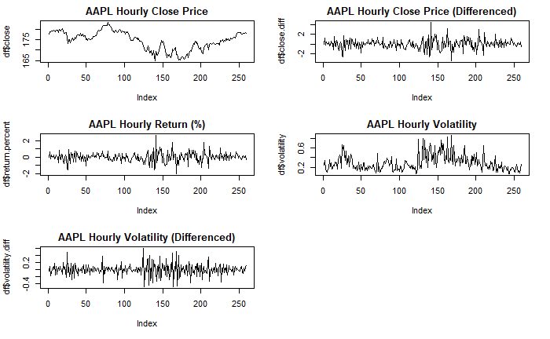

```r
## View basic plots of stock measures
plotResponses <- function(df, tick){
    par(mfrow=c(3,2))
    plot(df$close, type = 'l', main = paste(tick, "Hourly Close Price"))
    plot(df$close.diff, type = 'l', main = paste(tick, "Hourly Close Price (Differenced)"))
    plot(df$return.percent, type = 'l', main = paste(tick, "Hourly Return (%)"))
    plot(df$volatility, type = 'l', main = paste(tick, "Hourly Volatility"))
    plot(df$volatility.diff, type = 'l', main = paste(tick, "Hourly Volatility (Differenced)"))
    par(mfrow=c(1,1))
}
plotResponses(AAPL.response, "AAPL")
```

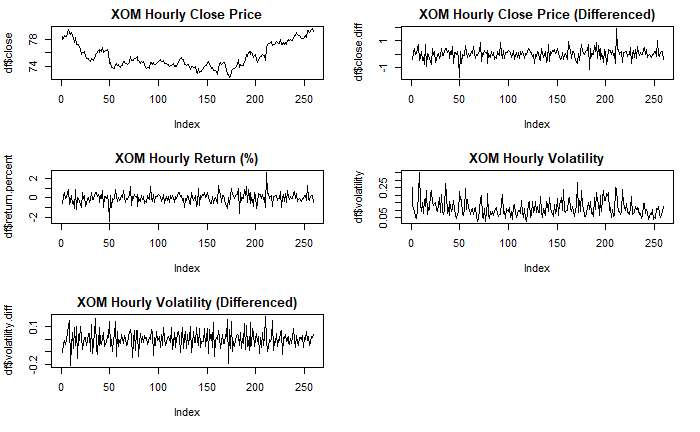

```r
plotResponses(XOM.response, "XOM")
```

With relevant stock measures compiled since 2-26-2018, I next merged my sentiment scores and stock measures together. This was performed by merging on date and hour and keeping only date/hour combinations present in the stock measure data. Though now removing off hour sentiment observations (e.g. night and weekend), including 72 hours of lagged sentiment data ensures I still have insight to off hour sentiment to predict stock measures during standard trade hours.

Train and test splits were also derived at this time. Data to be used for training and cross-validation purposes were identified as observations between 2-26-2018 and 4-4-2018. Data to be used strictly for prediction purposes were identified as observations from 4-5-2018 through 4-13-2018. This amounted to approximately 80% of the data available being used for training and about 20% being used for testing. While splitting train and test datasets, I also filled NA sentiment scores with zeroes (NA values were present due to the date/hour filling operation performed earlier that added placeholders for date/hour combinations during which no social media or news messages had been posted) and updated sentiment score column names to be compatible with the modeling functions used later.

All these operations are included in the *mergeSentiment* function below.

```r
## Merge sentiment data with stock data for model development
mergeSentiment <- function(df, tick){
    tickSent <- readRDS(paste0('Data/TickerRDS/', tick, '.RDS'))

    ## Start with training data
    tickSent.train <- merge(tickSent, df[, c("date",
                                             "hour",
                                             "close",
                                             "close.diff",
                                             "return.percent",
                                             "volatility",
                                             "volatility.diff")],
                            by = c("date", "hour"), all.y = TRUE) #Keep only rows containing stock price (since sentiment was lagged before this, we still have lagged sentiment effects)
    tickSent.train <- tickSent.train[tickSent.train$date > "2018-02-26" & tickSent.train$date <= "2018-04-04",] #Incomplete sentiment data before 2-26-18
    tickSent.train[is.na(tickSent.train)] <- 0 #Fill any NA sentiment scores with 0
    colnames(tickSent.train) <- gsub(x = colnames(tickSent.train), pattern = "-", replacement = "N") #randomForest function doesn't like '-' in colnames
    tickSent.train <- tickSent.train[with(tickSent.train, order(date, hour)),]

    ## Create prediction dataset next
    tickSent.pred <- merge(tickSent, df[, c("date",
                                            "hour",
                                            "close",
                                            "close.diff",
                                            "return.percent",
                                            "volatility",
                                            "volatility.diff")],
                           by = c("date", "hour"), all.y = TRUE) #Keep only rows containing stock price (since sentiment was lagged before this, we still have lagged sentiment effects)
    tickSent.pred <- tickSent.pred[tickSent.pred$date > "2018-04-04" & tickSent.pred$date <= "2018-04-13",] #20% of data set aside for predictions
    tickSent.pred[is.na(tickSent.pred)] <- 0 #Fill any NA sentiment scores with 0
    colnames(tickSent.pred) <- gsub(x = colnames(tickSent.pred), pattern = "-", replacement = "N") #randomForest function doesn't like '-' in colnames
    tickSent.pred <- tickSent.pred[with(tickSent.pred, order(date, hour)),]

    return(list(tickSent.train, tickSent.pred))
}

AAPL <- mergeSentiment(AAPL.response, "AAPL")
XOM <- mergeSentiment(XOM.response, "XOM")
```

#### Check Data Stationarity

As in the previous project, I again assessed data stationarity in Project 2. While most column indices have p-values less than 0.05, there are indeed some with p-values exceeding this 95% confidence threshold. For example, hourly closing price data (5th to last index) is suggested as being non-stationary with 95% confidence for the standard Dickey-Fuller test for both AAPL and XOM. Reviewing Augmented Dickey-Fuller (ADF) results reveals closing price may not be the only response variable which is non-stationary. The ADF results for AAPL suggest that volatility (2nd to last index) is also non-stationary for AAPL, whereas non-stationarity is not a concern for XOM. Finally, there are a small number of lagged sentiment data columns which seem to be non-stationary.

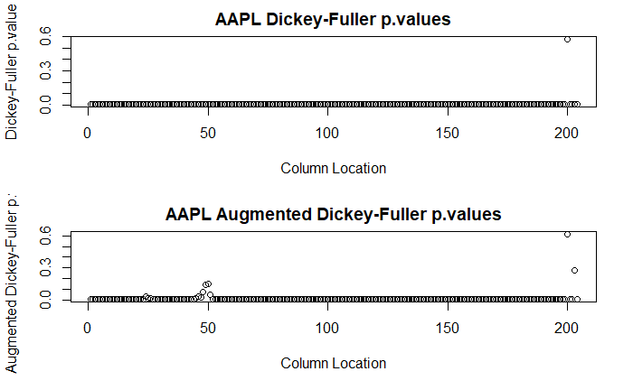

```r
## Perform Dickey-Fuller and Augmented Dickey-Fuller tests
doDickey <- function(tickSent.train, tickSent.pred, tick){
    par(mfrow=c(2,1))
    #pdf(paste0('Stationarity_', tick, '.pdf'))
    temp <- apply(rbind(tickSent.train[2:length(tickSent.train)],tickSent.pred[2:length(tickSent.pred)]), 2, adf.test, alternative = "stationary", k=0)
    plot(sapply(temp, function(x) x$p.value), xlab = "Column Location", ylab = "Dickey-Fuller p.value", main = paste(tick, "Dickey-Fuller p.values"))
    temp <- apply(rbind(tickSent.train[2:length(tickSent.train)],tickSent.pred[2:length(tickSent.pred)]), 2, adf.test, alternative = "stationary")
    plot(sapply(temp, function(x) x$p.value), xlab = "Column Location", ylab = "Augmented Dickey-Fuller p.value", main = paste(tick, "Augmented Dickey-Fuller p.values"))
}
doDickey(AAPL[[1]], AAPL[[2]], "AAPL")
```

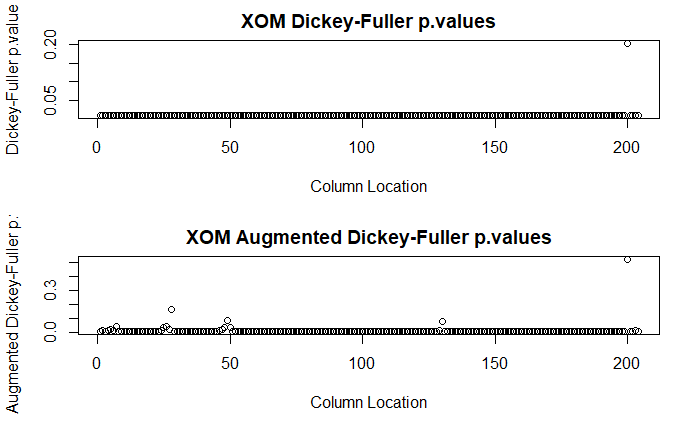

```r
doDickey(XOM[[1]], XOM[[2]], "XOM")
```

The reason some lagged scores ended up being non-stationary but other lagged scores did not is likely due in part to the fact that scores were lagged prior to combining price data, after which non-trade hour date/hour combinations were dropped. This may have caused some breaks in the lagged data at intervals, potentially introducing non-stationary patterns that are not true to the full sentiment dataset itself. Given the nature of the application and purpose of the lagged sentiment data, however, I deemed this acceptable and chose not to difference these sentiment data. Instead, as was done during the *getStockData* and *addVolatility* functions, closing price and volatility were both differenced in preparation for modeling.

#### Random Forest Regression Model

After the most accurate *mtry* value was identified via my cross-validated grid search training methodology, I also computed R-squared, MSE, RMSE, MAE, and MAPE values for both cross-validated training data as well as the data set aside earlier for prediction purposes (dates 4-5-2018 through 4-13-2018). Predicted vs. actual values were plotted to PDF for visual R-squared evaluation on both cross-validated training data and prediction data. Next, I also plotted the actual hourly ticker data compared to the modeled values with respect to time (See *RFplots_* prefixed PDFs). This was done to indicate performance against both training and prediction data. When differenced price and volatility data were being predicted, the differenced plot outputs were back-transformed to compare apples-to-apples with non-differenced model performance (used cumulative sum calculation for this). However, this method proved sensitive to any large swings in predicted value which did not swing equally as strong back in the opposite direction to re-align the differenced, cumulatively summed plot with non-differenced data. Therefore, I found it most useful to assess differenced actual vs. modeled plots when assessing differenced price and differenced volatility model performance.

Finally, feature importance rankings were also saved for the best model based on cross-validated, grid searched training. These feature rankings are later exported to Tableau for thorough review.

```r
doRF <- function(train.df, pred.df, tick, response, formula, metric,
                 xform = "", orig.train.df = train.df, orig.pred.df = pred.df,
                 orig.response = response){
    tryCatch({
        ## Write outputs to external files for later review
        par(mfrow=c(1,1))
        sink(paste0("doRF_", tick, response, "_", metric, ".txt"))
        warningOut <- file(paste0("Warnings/doRF_", tick, response, "_", metric, "_warnings.txt"), open="wt")
        sink(warningOut, type = "message")
        pdf(paste0('RFplots_',tick, response, '_', metric, '.pdf'))

        ## Flow and plots inspired by and modified from http://blog.yhat.com/posts/comparing-random-forests-in-python-and-r.html
        ## Setup data
        cols <- colnames(train.df)
        cols <- cols[!cols %in% "date"]

        ## Create Random Forest Seeds
        # Seeding and timeslice methodology inspired by https://rpubs.com/crossxwill/time-series-cv
        set.seed(123)
        seeds <- vector(mode = "list", length = 79) #Length based on number of resamples + 1 for final model iteration
        for(i in 1:78) seeds[[i]] <- sample.int(1000, 72) #sample.int second argument value based on expand.grid length
        seeds[[79]] <- sample.int(1000, 1)

        ## Setup training parameters
        ts.control <- trainControl(method="timeslice", initialWindow = 98, horizon = 7,
                                   fixedWindow = FALSE, allowParallel = TRUE, seeds = seeds,
                                   search = "grid") #98 hour initial cv training, 7 hour cv testing
        tuneGridRF <- expand.grid(.mtry=c(1:72))
        #metric <- "Rsquared"

        ## Perform training
        start <- Sys.time() #Start timer
        rf <- train(formula, data = train.df[,cols], method = "rf", metric = metric, trControl = ts.control,
                    tuneGrid = tuneGridRF, importance=TRUE)
        print(Sys.time() - start)

        cat("\nRF Output\n")
        print(rf)
        print(plot(rf))

        ## Evaluate metrics
        r2.train <- rSquared(train.df[,response], train.df[,response] - predict(rf, train.df[,cols]))
        r2.pred <- rSquared(pred.df[,response], pred.df[,response] - predict(rf, pred.df[,cols]))
        mse.train <- mean((train.df[,response] - predict(rf, train.df[,cols]))^2)
        mse.pred <- mean((pred.df[,response] - predict(rf, pred.df[,cols]))^2)
        rmse.train <- sqrt(mse.train)
        rmse.pred <- sqrt(mse.pred)
        mae.train <- mean(abs(train.df[,response] - predict(rf, train.df[,cols])))
        mae.pred <- mean(abs(pred.df[,response] - predict(rf, pred.df[,cols])))
        mape.train <- MAPE(train.df[,response], predict(rf, train.df[,cols]))
        mape.pred <- MAPE(pred.df[,response], predict(rf, pred.df[,cols]))

        ## Plot Rsquared Evaluation
        p <- ggplot(aes(x=actual, y=pred),
                    data=data.frame(actual=train.df[,response], pred=predict(rf, train.df[,cols])))
        print(p + geom_point() +
            geom_abline(color="red") +
            ggtitle(paste(tick, response, "RandomForest Regression: Training r^2 =", r2.train)))

        p <- ggplot(aes(x=actual, y=pred),
                    data=data.frame(actual=pred.df[,response], pred=predict(rf, pred.df[,cols])))
        print(p + geom_point() +
            geom_abline(color="red") +
            ggtitle(paste(tick, response, "RandomForest Regression: Prediction r^2 =", r2.pred)))

        if(xform == "diff"){
            ## Plot trained and predicted performance
            plot(as.numeric(c(cumsum(c(orig.train.df[,orig.response][1], train.df[,response])),
                              cumsum(c(orig.pred.df[,orig.response][1], pred.df[,response])))),
                 type = "l", lty = 1, xlab = "Date & Hour",
                 ylab = paste0("Cumulative Sum of ", orig.response, "[1] and DIff = ", orig.response),
                 xaxt = "n", main = paste0(tick, " RF Performance (", response, "): Training + Prediction"))
            axis(1, at=1:(sum(length(train.df[,response]), length(pred.df[,response]))), labels=FALSE)
            text(1:(sum(length(train.df[,response]), length(pred.df[,response]))), par("usr")[3] - 0.2,
                 labels = c(paste(train.df$date, train.df$hour), paste(pred.df$date, pred.df$hour)),
                 srt = 90, pos = 2, xpd = TRUE, cex = 0.5, offset = -0.1)
            lines(c(cumsum(c(orig.train.df[,orig.response][1], predict(rf, train.df[,cols]))),
                    cumsum(c(orig.pred.df[,orig.response][1], predict(rf, pred.df[,cols])))),
                  type = "l", lty = 2, lwd = 2, col = "red")
            abline(v = length(train.df[,response])+1, lty = 2, col = "blue")

            ## Plot just predicted performance
            plot(as.numeric(cumsum(c(orig.pred.df[,orig.response][1], pred.df[,response]))),
                 type = "l", lty = 1, xlab = "Date & Hour",
                 ylab = paste0("Cumulative Sum of ", orig.response, "[1] and DIff = ", orig.response),
                 xaxt = "n", ylim = c(min(c(cumsum(c(orig.pred.df[,orig.response][1], predict(rf, pred.df[,cols]))),
                                            cumsum(c(orig.pred.df[,orig.response][1], pred.df[,response])))),
                                      max(c(cumsum(c(orig.pred.df[,orig.response][1], predict(rf, pred.df[,cols]))),
                                            cumsum(c(orig.pred.df[,orig.response][1], pred.df[,response]))))),
                 main = paste0(tick, " RF Performance (", response, "): Prediction"))
            axis(1, at=1:(length(pred.df[,response])), labels=FALSE)
            text(1:(length(pred.df[,response])), par("usr")[3] - 0.2, labels = paste(pred.df$date, pred.df$hour),
                 srt = 90, pos = 2, xpd = TRUE, cex = 0.6, offset = -0.1)
            lines(cumsum(c(orig.pred.df[,orig.response][1], predict(rf, pred.df[,cols]))),
                  type = "l", lty = 2, lwd = 2, col = "red")
        }

        ## Plot trained and predicted performance
        plot(as.numeric(c(train.df[,response], pred.df[,response])), type = "l", lty = 1,
             xlab = "Date & Hour", ylab = response, xaxt = "n",
             main = paste0(tick, " RF Performance (", response, "): Training + Prediction"))
        axis(1, at=1:(sum(length(train.df[,response]), length(pred.df[,response]))), labels=FALSE)
        text(1:(sum(length(train.df[,response]), length(pred.df[,response]))), par("usr")[3] - 0.2,
             labels = c(paste(train.df$date, train.df$hour), paste(pred.df$date, pred.df$hour)),
             srt = 90, pos = 2, xpd = TRUE, cex = 0.5, offset = -0.1)
        lines(c(predict(rf, train.df[,cols]),predict(rf, pred.df[,cols])), type = "l", lty = 2, lwd = 2, col = "red")
        abline(v = length(train.df[,response])+1, lty = 2, col = "blue")

        ## Plot just predicted performance
        plot(as.numeric(pred.df[,response]), type = "l", lty = 1, xlab = "Date & Hour", ylab = response,
             xaxt = "n", ylim = c(min(c(predict(rf, pred.df[,cols]), pred.df[,response])),
                                  max(c(predict(rf, pred.df[,cols]), pred.df[,response]))),
             main = paste0(tick, " RF Performance (", response, "): Prediction"))
        axis(1, at=1:(length(pred.df[,response])), labels=FALSE)
        text(1:(length(pred.df[,response])), par("usr")[3] - 0.2, labels = paste(pred.df$date, pred.df$hour),
             srt = 90, pos = 2, xpd = TRUE, cex = 0.6, offset = -0.1)
        lines(predict(rf, pred.df[,cols]), type = "l", lty = 2, lwd = 2, col = "red")

        ## Get feature importance
        feat.imp <- varImp(rf)
        plot(feat.imp, main = paste(tick, response, "RF Feature Importance"))

        on.exit(dev.off())
        on.exit(sink(type="message"), add = TRUE)
        on.exit(close(warningOut), add = TRUE)
        on.exit(sink(), add = TRUE)
    }, error = function(e){
        on.exit(dev.off())
        on.exit(sink(type="message"), add = TRUE)
        on.exit(close(warningOut), add = TRUE)
        on.exit(sink(), add = TRUE)
        print(paste(tick, response, "RF failed"))
    })

    return(list(rf, list(r2.train, r2.pred), list(mse.train, mse.pred), list(rmse.train, rmse.pred),
                list(mae.train, mae.pred), list(mape.train, mape.pred), feat.imp))
}
```

The above *doRF* function was called via several combinations of ticker, response measure (closing price, differenced closing price, percent return, and differenced volatility), and R-squared vs. RMSE evaluation metrics as depicted below.

```r
startOverall <- Sys.time() #Start Overall timer

## Predict 'close'
setup_close <- function(){
    notResponse <- c("close.diff", "return.percent", "volatility", "volatility.diff")
    assign("AAPL.train", AAPL[[1]][,!(names(AAPL[[1]]) %in% notResponse)], envir=.GlobalEnv)
    assign("AAPL.pred", AAPL[[2]][,!(names(AAPL[[2]]) %in% notResponse)], envir=.GlobalEnv)
    assign("XOM.train", XOM[[1]][,!(names(XOM[[1]]) %in% notResponse)], envir=.GlobalEnv)
    assign("XOM.pred", XOM[[2]][,!(names(XOM[[2]]) %in% notResponse)], envir=.GlobalEnv)
}
setup_close()

AAPL.close.rf.Rsquared <- doRF(AAPL.train, AAPL.pred, "AAPL", "close", close ~ ., "Rsquared")
XOM.close.rf.Rsquared <- doRF(XOM.train, XOM.pred, "XOM", "close", close ~ ., "Rsquared")
AAPL.close.rf.RMSE <- doRF(AAPL.train, AAPL.pred, "AAPL", "close", close ~ ., "RMSE")
XOM.close.rf.RMSE <- doRF(XOM.train, XOM.pred, "XOM", "close", close ~ ., "RMSE")

## Predict 'close.diff'
setup_close.diff <- function(){
    notResponse <- c("close", "return.percent", "volatility", "volatility.diff")
    assign("AAPL.train", AAPL[[1]][,!(names(AAPL[[1]]) %in% notResponse)], envir=.GlobalEnv)
    assign("AAPL.pred", AAPL[[2]][,!(names(AAPL[[2]]) %in% notResponse)], envir=.GlobalEnv)
    assign("XOM.train", XOM[[1]][,!(names(XOM[[1]]) %in% notResponse)], envir=.GlobalEnv)
    assign("XOM.pred", XOM[[2]][,!(names(XOM[[2]]) %in% notResponse)], envir=.GlobalEnv)

    notResponse <- c("close.diff", "return.percent", "volatility", "volatility.diff")
    assign("AAPL.train.adder", AAPL[[1]][,!(names(AAPL[[1]]) %in% notResponse)], envir=.GlobalEnv)
    assign("AAPL.pred.adder", AAPL[[2]][,!(names(AAPL[[2]]) %in% notResponse)], envir=.GlobalEnv)
    assign("XOM.train.adder", XOM[[1]][,!(names(XOM[[1]]) %in% notResponse)], envir=.GlobalEnv)
    assign("XOM.pred.adder", XOM[[2]][,!(names(XOM[[2]]) %in% notResponse)], envir=.GlobalEnv)
}
setup_close.diff()

AAPL.closediff.rf.Rsquared <- doRF(AAPL.train, AAPL.pred, "AAPL", "close.diff", close.diff ~ ., "Rsquared",
                                   "diff", AAPL.train.adder, AAPL.pred.adder, "close")
XOM.closediff.rf.Rsquared <- doRF(XOM.train, XOM.pred, "XOM", "close.diff", close.diff ~ ., "Rsquared",
                                  "diff", XOM.train.adder, XOM.pred.adder, "close")
AAPL.closediff.rf.RMSE <- doRF(AAPL.train, AAPL.pred, "AAPL", "close.diff", close.diff ~ ., "RMSE",
                               "diff", AAPL.train.adder, AAPL.pred.adder, "close")
XOM.closediff.rf.RMSE <- doRF(XOM.train, XOM.pred, "XOM", "close.diff", close.diff ~ ., "RMSE",
                              "diff", XOM.train.adder, XOM.pred.adder, "close")

## Predict 'return.percent'
setup_return.percent <- function(){
    notResponse <- c("close", "close.diff", "volatility", "volatility.diff")
    assign("AAPL.train", AAPL[[1]][,!(names(AAPL[[1]]) %in% notResponse)], envir=.GlobalEnv)
    assign("AAPL.pred", AAPL[[2]][,!(names(AAPL[[2]]) %in% notResponse)], envir=.GlobalEnv)
    assign("XOM.train", XOM[[1]][,!(names(XOM[[1]]) %in% notResponse)], envir=.GlobalEnv)
    assign("XOM.pred", XOM[[2]][,!(names(XOM[[2]]) %in% notResponse)], envir=.GlobalEnv)
}
setup_return.percent()

AAPL.returnpercent.rf.Rsquared <- doRF(AAPL.train, AAPL.pred, "AAPL", "return.percent", return.percent ~ ., "Rsquared")
XOM.returnpercent.rf.Rsquared <- doRF(XOM.train, XOM.pred, "XOM", "return.percent", return.percent ~ ., "Rsquared")
AAPL.returnpercent.rf.RMSE <- doRF(AAPL.train, AAPL.pred, "AAPL", "return.percent", return.percent ~ ., "RMSE")
XOM.returnpercent.rf.RMSE <- doRF(XOM.train, XOM.pred, "XOM", "return.percent", return.percent ~ ., "RMSE")

## Predict 'volatility.diff'
setup_volatility.diff <- function(){
    notResponse <- c("close", "close.diff", "return.percent", "volatility")
    assign("AAPL.train", AAPL[[1]][,!(names(AAPL[[1]]) %in% notResponse)], envir=.GlobalEnv)
    assign("AAPL.pred", AAPL[[2]][,!(names(AAPL[[2]]) %in% notResponse)], envir=.GlobalEnv)
    assign("XOM.train", XOM[[1]][,!(names(XOM[[1]]) %in% notResponse)], envir=.GlobalEnv)
    assign("XOM.pred", XOM[[2]][,!(names(XOM[[2]]) %in% notResponse)], envir=.GlobalEnv)

    notResponse <- c("close", "close.diff", "return.percent", "volatility.diff")
    assign("AAPL.train.adder", AAPL[[1]][,!(names(AAPL[[1]]) %in% notResponse)], envir=.GlobalEnv)
    assign("AAPL.pred.adder", AAPL[[2]][,!(names(AAPL[[2]]) %in% notResponse)], envir=.GlobalEnv)
    assign("XOM.train.adder", XOM[[1]][,!(names(XOM[[1]]) %in% notResponse)], envir=.GlobalEnv)
    assign("XOM.pred.adder", XOM[[2]][,!(names(XOM[[2]]) %in% notResponse)], envir=.GlobalEnv)
}
setup_volatility.diff()

AAPL.volatilitydiff.rf.Rsquared <- doRF(AAPL.train, AAPL.pred, "AAPL", "volatility.diff", volatility.diff ~ .,
                                        "Rsquared", "diff", AAPL.train.adder, AAPL.pred.adder, "volatility")
XOM.volatilitydiff.rf.Rsquared <- doRF(XOM.train, XOM.pred, "XOM", "volatility.diff", volatility.diff ~ .,
                                       "Rsquared", "diff", XOM.train.adder, XOM.pred.adder, "volatility")
AAPL.volatilitydiff.rf.RMSE <- doRF(AAPL.train, AAPL.pred, "AAPL", "volatility.diff", volatility.diff ~ .,
                                    "RMSE", "diff", AAPL.train.adder, AAPL.pred.adder, "volatility")
XOM.volatilitydiff.rf.RMSE <- doRF(XOM.train, XOM.pred, "XOM", "volatility.diff", volatility.diff ~ .,
                                   "RMSE", "diff", XOM.train.adder, XOM.pred.adder, "volatility")

print(Sys.time() - startOverall)
```

An example plotted output via the *doRF* function calls is as follows. The example shown below is for the AAPL hourly closing price (To see all outputs, please refer to the *RFplots_* PDF file outputs included with this project’s submission).

[figure not shown]

AAPL, Closing Price, Rsquared RF Model Evaluation Output

Random Forest models and other *doRF* returned outputs were saved to RDS files after generation to avoid needing to re-run the code multiple times since run time was about 9 hours for Random Forest model generation on my PC.

```r
## Save models and metrics to external RDS
for(m in ls(pattern = '\\.rf\\.')){
    saveRDS(get(m), paste0('Data/ModelRDS/', m, '.RDS'))
}
```

#### Extreme Gradient Boosting Regression Model

As was done for random forest, R-squared, MSE, RMSE, MAE, and MAPE metrics were calculated for both cross-validated training data and prediction data. Visual R-squared evaluation plots and actual vs. predicted stock closing prices, differenced closing prices, percent returns, and differenced volatility were plotted to PDF for both training and prediction datasets (See *XGBplots_* prefixed PDFs). Finally, feature importance rankings were captured (except in cases where the algorithm was unable to produce reliable results given the hyperparameter values used in the grid search and data combination produced a constant tree; see https://github.com/dmlc/xgboost/issues/2876).

```r
doXGB <- function(train.df, pred.df, tick, response, metric, xform = "",
                  orig.train.df = train.df, orig.pred.df = pred.df, orig.response = response){
    tryCatch({
        ## Write outputs to external files for later review
        sink(paste0("doXGB_", tick, response, "_", metric, ".txt"))
        warningOut <- file(paste0("Warnings/doXGB_", tick, response, "_", metric, "_warnings.txt"), open="wt")
        sink(warningOut, type = "message")
        pdf(paste0('XGBplots_',tick, response, '_', metric, '.pdf'))

        ## Flow and plots inspired by and modified from http://blog.yhat.com/posts/comparing-random-forests-in-python-and-r.html
        ## Setup data
        cols <- colnames(train.df)
        cols <- cols[!cols %in% c("date", response)]
        X.train <- data.matrix(train.df[,cols])
        X.test <- data.matrix(pred.df[,cols])
        Y.train <- train.df[,response]
        Y.test <- pred.df[,response]

        ## Create seeds
        set.seed(123)
        seeds <- vector(mode = "list", length = 79) #Length based on number of resamples + 1 for final model iteration
        for(i in 1:78) seeds[[i]] <- sample.int(1000, 12) #sample.int second argument value based on expand.grid nrows
        seeds[[79]] <- sample.int(1000, 1)

        ## Setup training parameters
        ts.control <- trainControl(method="timeslice", initialWindow = 98, horizon = 7,
                                   fixedWindow = FALSE, allowParallel = TRUE, seeds = seeds,
                                   search = "grid") #98 day cv training, 7 day cv testing
        tuneGridXGB <- expand.grid( #See parameter descriptions at http://xgboost.readthedocs.io/en/latest/parameter.html
            nrounds=350,
            eta = c(0.3, 0.5),
            gamma = c(0, 1, 5),
            max_depth = 6,
            colsample_bytree = c(0.5, 1),
            subsample = 0.5,
            min_child_weight = 1)

        ## Perform training
        start <- Sys.time() #Start timer
        xgbmod <- train(
            x = X.train,
            y = as.numeric(Y.train),
            method = 'xgbTree',
            metric = metric,
            trControl = ts.control,
            tuneGrid = tuneGridXGB,
            importance=TRUE)
        print(Sys.time() - start)
        cat("\nXGB Output\n")
        print(xgbmod)
        print(plot(xgbmod))

        ## Evaluate metrics
        r2.train <- rSquared(Y.train, Y.train - predict(xgbmod, X.train))
        r2.pred <- rSquared(Y.test, Y.test - predict(xgbmod, X.test))
        mse.train <- mean((Y.train - predict(xgbmod, X.train))^2)
        mse.pred <- mean((Y.test - predict(xgbmod, X.test))^2)
        rmse.train <- sqrt(mse.train)
        rmse.pred <- sqrt(mse.pred)
        mae.train <- mean(abs(Y.train - predict(xgbmod, X.train)))
        mae.pred <- mean(abs(Y.test - predict(xgbmod, X.test)))
        mape.train <- MAPE(Y.train, predict(xgbmod, X.train))
        mape.pred <- MAPE(Y.test, predict(xgbmod, X.test))

        ## Plot Rsquared Evaluation
        p <- ggplot(aes(x=actual, y=pred),
                    data=data.frame(actual=Y.train, pred=predict(xgbmod, X.train)))
        print(p + geom_point() +
            geom_abline(color="red") +
            ggtitle(paste(tick, response, "XGBoost Regression in R r^2 =", r2.train)))

        p <- ggplot(aes(x=actual, y=pred),
                    data=data.frame(actual=Y.test, pred=predict(xgbmod, X.test)))
        print(p + geom_point() +
            geom_abline(color="red") +
            ggtitle(paste(tick, response, "XGBoost Regression in R r^2 =", r2.pred)))

        if(xform == "diff"){
            ## Plot trained and predicted performance
            plot(as.numeric(c(cumsum(c(orig.train.df[,orig.response][1], Y.train)),
                              cumsum(c(orig.pred.df[,orig.response][1], Y.test)))),
                 type = "l", lty = 1, xlab = "Date & Hour",
                 ylab = paste0("Cumulative Sum of ", orig.response, "[1] and DIff = ", orig.response),
                 xaxt = "n", main = paste0(tick, " XGBoost Performance (", response, "): Training + Prediction"))
            axis(1, at=1:(sum(length(Y.train), length(Y.test))), labels=FALSE)
            text(1:(sum(length(Y.train), length(Y.test))), par("usr")[3] - 0.2,
                 labels = c(paste(train.df$date, train.df$hour), paste(pred.df$date, pred.df$hour)),
                 srt = 90, pos = 2, xpd = TRUE, cex = 0.5, offset = -0.1)
            lines(c(cumsum(c(orig.train.df[,orig.response][1], predict(xgbmod, X.train))),
                    cumsum(c(orig.pred.df[,orig.response][1], predict(xgbmod, X.test)))),
                  type = "l", lty = 2, lwd = 2, col = "red")
            abline(v = length(Y.train)+1, lty = 2, col = "blue")

            ## Plot just predicted performance
            plot(as.numeric(cumsum(c(orig.pred.df[,orig.response][1], Y.test))), type = "l",
                 lty = 1, xlab = "Date & Hour",
                 ylab = paste0("Cumulative Sum of ", orig.response, "[1] and DIff = ", orig.response),
                 xaxt = "n", ylim = c(min(c(cumsum(c(orig.pred.df[,orig.response][1], predict(xgbmod, X.test))),
                                            cumsum(c(orig.pred.df[,orig.response][1], Y.test)))),
                                      max(c(cumsum(c(orig.pred.df[,orig.response][1], predict(xgbmod, X.test))),
                                            cumsum(c(orig.pred.df[,orig.response][1], Y.test))))),
                 main = paste0(tick, " XGBoost Performance (", response, "): Prediction"))
            axis(1, at=1:(length(Y.test)), labels=FALSE)
            text(1:(length(Y.test)), par("usr")[3] - 0.2, labels = paste(pred.df$date, pred.df$hour),
                 srt = 90, pos = 2, xpd = TRUE, cex = 0.6, offset = -0.1)
            lines(cumsum(c(orig.pred.df[,orig.response][1], predict(xgbmod, X.test))), type = "l", lty = 2, lwd = 2, col = "red")
        }

        ## Plot trained and predicted performance
        plot(as.numeric(c(Y.train, Y.test)), type = "l", lty = 1, xlab = "Date & Hour",
             ylab = response, xaxt = "n",
             main = paste0(tick, " XGBoost Performance (", response, "): Training + Prediction"))
        axis(1, at=1:(sum(length(Y.train), length(Y.test))), labels=FALSE)
        text(1:(sum(length(Y.train), length(Y.test))), par("usr")[3] - 0.2,
             labels = c(paste(train.df$date, train.df$hour), paste(pred.df$date, pred.df$hour)),
             srt = 90, pos = 2, xpd = TRUE, cex = 0.5, offset = -0.1)
        lines(c(predict(xgbmod, train.df[,cols]),predict(xgbmod, X.test)), type = "l",
              lty = 2, lwd = 2, col = "red")
        abline(v = length(Y.train)+1, lty = 2, col = "blue")

        ## Plot just predicted performance
        plot(as.numeric(Y.test), type = "l", lty = 1, xlab = "Date & Hour", ylab = response,
             xaxt = "n", ylim = c(min(c(predict(xgbmod, X.test), Y.test)),
                                  max(c(predict(xgbmod, X.test), Y.test))),
             main = paste0(tick, " XGBoost Performance (", response, "): Prediction"))
        axis(1, at=1:(length(Y.test)), labels=FALSE)
        text(1:(length(Y.test)), par("usr")[3] - 0.2, labels = paste(pred.df$date, pred.df$hour),
             srt = 90, pos = 2, xpd = TRUE, cex = 0.6, offset = -0.1)
        lines(predict(xgbmod, X.test), type = "l", lty = 2, lwd = 2, col = "red")

        tryCatch({
            feat.imp <- varImp(xgbmod)
            print(plot(feat.imp, main = paste(tick, "XGBoost Feature Importance")))

            on.exit(dev.off())
            on.exit(sink(type="message"), add = TRUE)
            on.exit(close(warningOut), add = TRUE)
            on.exit(sink(), add = TRUE)
            return(list(xgbmod, list(r2.train, r2.pred), list(mse.train, mse.pred),
                        list(rmse.train, rmse.pred), list(mae.train, mae.pred),
                        list(mape.train, mape.pred), feat.imp))
        }, error = function(e){
            on.exit(dev.off())
            on.exit(sink(type="message"), add = TRUE)
            on.exit(close(warningOut), add = TRUE)
            on.exit(sink(), add = TRUE)
            return(list(xgbmod, list(r2.train, r2.pred), list(mse.train, mse.pred),
                        list(rmse.train, rmse.pred), list(mae.train, mae.pred),
                        list(mape.train, mape.pred), NA))
        })
    }, error = function(e){
        on.exit(dev.off())
        on.exit(sink(type="message"), add = TRUE)
        on.exit(close(warningOut), add = TRUE)
        on.exit(sink(), add = TRUE)
        print(paste(tick, response, "XGB failed"))
    })

}
```

Similar to random forest and its associated function, the above *doXGB* function was called via several combinations of ticker, response measure (closing price, differenced closing price, percent return, and differenced volatility), and R-squared vs. RMSE evaluation metrics as depicted below.

```r
startOverall <- Sys.time() #Start Overall timer

## Predict 'close'
setup_close()

AAPL.close.xgb.Rsquared <- doXGB(AAPL.train, AAPL.pred, "AAPL", "close", "Rsquared")
XOM.close.xgb.Rsquared <- doXGB(XOM.train, XOM.pred, "XOM", "close", "Rsquared")
AAPL.close.xgb.RMSE <- doXGB(AAPL.train, AAPL.pred, "AAPL", "close", "RMSE")
XOM.close.xgb.RMSE <- doXGB(XOM.train, XOM.pred, "XOM", "close", "RMSE")

## Predict 'close.diff'
setup_close.diff()

AAPL.closediff.xgb.Rsquared <- doXGB(AAPL.train, AAPL.pred, "AAPL", "close.diff", "Rsquared", "diff", AAPL.train.adder, AAPL.pred.adder, "close")
XOM.closediff.xgb.Rsquared <- doXGB(XOM.train, XOM.pred, "XOM", "close.diff", "Rsquared", "diff", XOM.train.adder, XOM.pred.adder, "close")
AAPL.closediff.xgb.RMSE <- doXGB(AAPL.train, AAPL.pred, "AAPL", "close.diff", "RMSE", "diff", AAPL.train.adder, AAPL.pred.adder, "close")
XOM.closediff.xgb.RMSE <- doXGB(XOM.train, XOM.pred, "XOM", "close.diff", "RMSE", "diff", XOM.train.adder, XOM.pred.adder, "close")

## Predict 'return.percent'
setup_return.percent()

AAPL.returnpercent.xgb.Rsquared <- doXGB(AAPL.train, AAPL.pred, "AAPL", "return.percent", "Rsquared")
XOM.returnpercent.xgb.Rsquared <- doXGB(XOM.train, XOM.pred, "XOM", "return.percent", "Rsquared")
AAPL.returnpercent.xgb.RMSE <- doXGB(AAPL.train, AAPL.pred, "AAPL", "return.percent", "RMSE")
XOM.returnpercent.xgb.RMSE <- doXGB(XOM.train, XOM.pred, "XOM", "return.percent", "RMSE")

## Predict 'volatility.diff'
setup_volatility.diff()

AAPL.volatilitydiff.xgb.Rsquared <- doXGB(AAPL.train, AAPL.pred, "AAPL", "volatility.diff", "Rsquared", "diff", AAPL.train.adder, AAPL.pred.adder, "volatility")
XOM.volatilitydiff.xgb.Rsquared <- doXGB(XOM.train, XOM.pred, "XOM", "volatility.diff", "Rsquared", "diff", XOM.train.adder, XOM.pred.adder, "volatility")
AAPL.volatilitydiff.xgb.RMSE <- doXGB(AAPL.train, AAPL.pred, "AAPL", "volatility.diff", "RMSE", "diff", AAPL.train.adder, AAPL.pred.adder, "volatility")
XOM.volatilitydiff.xgb.RMSE <- doXGB(XOM.train, XOM.pred, "XOM", "volatility.diff", "RMSE", "diff", XOM.train.adder, XOM.pred.adder, "volatility")

print(Sys.time() - startOverall)
```

An example plotted output via the *doXGB* function calls is as follows. The example shown below is for the AAPL hourly closing price (To see all outputs, please refer to the *XGBplots_* PDF file outputs included with this project’s submission).

[figure not shown]

AAPL, Closing Price, Rsquared XGB Model Evaluation Output

Extreme Gradient Boosting models and other *doXGB* returned outputs were saved to RDS files after generation to avoid needing to re-run the code multiple times since run time was about 7 hours for XGB model generation on my PC.

```r
## Save models and metrics to external RDS
for(m in ls(pattern = '\\.xgb\\.')){
    saveRDS(get(m), paste0('Data/ModelRDS/', m, '.RDS'))
}
```

#### k-Nearest-Neighbors Regression Model

Again, the same methodology of timeslice cross-validation was used to train my kNN models in *doKNN*. Similar to the RF and XGB models, hyper-parameter tuning was performed to identify the model configuration which produces the best model. The parameter tuned in this case was *k*, representative of the number of neighbors to be used in model generation. As was done previously, R-squared, MSE, RMSE, MAE, and MAPE metrics were calculated for both cross-validated training data and prediction data, and visual R-squared evaluation plots and actual vs. predicted stock closing prices, differenced closing prices, percent returns, and differenced volatility were plotted to PDF for both training and prediction datasets (See *KNNplots_* prefixed PDFs). Finally, feature importance rankings were captured for later review in Tableau.

A key difference in how this model type was developed vs. the other models in my analysis is that I scaled all predictor and response variables during kNN model generation. This was necessary given kNN’s assessment of node distance to construct its regression model. Though I’ve left all stock measure plots and predictions in their scaled form, they still depict the same patterns and characteristics as their unscaled originators, just with scaled values instead.

```r
doKNN <- function(train.df, pred.df, tick, response, formula, metric, xform = "",
                  orig.train.df = train.df, orig.pred.df = pred.df, orig.response = response){
    tryCatch({
        ## Write outputs to external files for later review
        par(mfrow=c(1,1))
        sink(paste0("doKNN_", tick, response, "_", metric, ".txt"))
        warningOut <- file(paste0("Warnings/doKNN_", tick, response, "_", metric, "_warnings.txt"), open="wt")
        sink(warningOut, type = "message")
        pdf(paste0('KNNplots_',tick, response, '_', metric, '.pdf'))

        ## Flow and plots inspired by and modified from http://blog.yhat.com/posts/comparing-random-forests-in-python-and-r.html
        ## Setup data
        cols <- colnames(train.df)
        cols <- cols[!cols %in% "date"]

        ## Preprocess data used during evaluation
        pp.train.df <- preProcess(train.df, method = c("center", "scale"))
        pp.train.df <- predict(pp.train.df, train.df)
        pp.pred.df <- preProcess(pred.df, method = c("center", "scale"))
        pp.pred.df <- predict(pp.pred.df, pred.df)
        pp.orig.train.df <- preProcess(orig.train.df, method = c("center", "scale"))
        pp.orig.train.df <- predict(pp.orig.train.df, orig.train.df)
        pp.orig.pred.df <- preProcess(orig.pred.df, method = c("center", "scale"))
        pp.orig.pred.df <- predict(pp.orig.pred.df, orig.pred.df)

        ## Create kNN Seeds
        # Seeding and timeslice methodology inspired by https://rpubs.com/crossxwill/time-series-cv
        set.seed(123)
        seeds <- vector(mode = "list", length = 79) #Length based on number of resamples + 1 for final model iteration
        for(i in 1:78) seeds[[i]] <- sample.int(1000, 72) #sample.int second argument value based on expand.grid length
        seeds[[79]] <- sample.int(1000, 1)

        ## Setup training parameters
        ts.control <- trainControl(method="timeslice", initialWindow = 98, horizon = 7,
                                   fixedWindow = FALSE, allowParallel = TRUE, seeds = seeds,
                                   search = "grid") #98 hour initial cv training, 7 hour cv testing
        tuneGridKNN <- expand.grid(k=c(1:72))

        ## Perform training
        start <- Sys.time() #Start timer
        knn <- train(formula, data = train.df[,cols], method = "knn", metric = metric,
                     trControl = ts.control, tuneGrid = tuneGridKNN, importance=TRUE, preProcess = c("center", "scale"))
        print(Sys.time() - start)

        cat("\nKNN Output\n")
        print(knn)
        print(plot(knn))

        ## Evaluate metrics
        r2.train <- rSquared(pp.train.df[,response], pp.train.df[,response] - scale(predict(knn, train.df[,cols])))
        r2.pred <- rSquared(pp.pred.df[,response], pp.pred.df[,response] - scale(predict(knn, pred.df[,cols])))
        mse.train <- mean((pp.train.df[,response] - scale(predict(knn, train.df[,cols])))^2)
        mse.pred <- mean((pp.pred.df[,response] - scale(predict(knn, pred.df[,cols])))^2)
        rmse.train <- sqrt(mse.train)
        rmse.pred <- sqrt(mse.pred)
        mae.train <- mean(abs(pp.train.df[,response] - scale(predict(knn, train.df[,cols]))))
        mae.pred <- mean(abs(pp.pred.df[,response] - scale(predict(knn, pred.df[,cols]))))
        mape.train <- MAPE(pp.train.df[,response], scale(predict(knn, train.df[,cols])))
        mape.pred <- MAPE(pp.pred.df[,response], scale(predict(knn, pred.df[,cols])))

        ## Plot Rsquared Evaluation
        p <- ggplot(aes(x=actual, y=pred),
                    data=data.frame(actual=pp.train.df[,response], pred=scale(predict(knn, train.df[,cols]))))
        print(p + geom_point() +
                  geom_abline(color="red") +
                  ggtitle(paste(tick, response, "KNN Regression: Training r^2 =", r2.train)))

        p <- ggplot(aes(x=actual, y=pred),
                    data=data.frame(actual=pp.pred.df[,response], pred=scale(predict(knn, pred.df[,cols]))))
        print(p + geom_point() +
                  geom_abline(color="red") +
                  ggtitle(paste(tick, response, "KNN Regression: Prediction r^2 =", r2.pred)))

        if(xform == "diff"){
            ## Plot trained and predicted performance
            plot(as.numeric(c(cumsum(c(pp.orig.train.df[,orig.response][1], pp.train.df[,response])),
                              cumsum(c(pp.orig.pred.df[,orig.response][1], pp.pred.df[,response])))),
                 type = "l", lty = 1, xlab = "Date & Hour",
                 ylab = paste0("Cumulative Sum of ", orig.response, "[1] and DIff = ", orig.response),
                 xaxt = "n", main = paste0(tick, " KNN Performance (", response, " scaled): Training + Prediction"))
            axis(1, at=1:(sum(length(pp.train.df[,response]), length(pp.pred.df[,response]))), labels=FALSE)
            text(1:(sum(length(pp.train.df[,response]), length(pp.pred.df[,response]))),
                 par("usr")[3] - 0.2, labels = c(paste(train.df$date, train.df$hour), paste(pred.df$date, pred.df$hour)),
                 srt = 90, pos = 2, xpd = TRUE, cex = 0.5, offset = -0.1)
            lines(c(cumsum(c(pp.orig.train.df[,orig.response][1], scale(predict(knn, train.df[,cols])))),
                    cumsum(c(pp.orig.pred.df[,orig.response][1], scale(predict(knn, pred.df[,cols]))))),
                  type = "l", lty = 2, lwd = 2, col = "red")
            abline(v = length(train.df[,response])+2, lty = 2, col = "blue")

            ## Plot just predicted performance
            plot(as.numeric(cumsum(c(pp.orig.pred.df[,orig.response][1], pp.pred.df[,response]))),
                 type = "l", lty = 1, xlab = "Date & Hour",
                 ylab = paste0("Cumulative Sum of ", orig.response, "[1] and DIff = ", orig.response),
                 xaxt = "n", ylim = c(min(c(cumsum(c(pp.orig.pred.df[,orig.response][1],
                                                     scale(predict(knn, pred.df[,cols])))),
                                            cumsum(c(pp.orig.pred.df[,orig.response][1],
                                                     pp.pred.df[,response])))),
                                      max(c(cumsum(c(pp.orig.pred.df[,orig.response][1],
                                                     scale(predict(knn, pred.df[,cols])))),
                                            cumsum(c(pp.orig.pred.df[,orig.response][1],
                                                     pp.pred.df[,response]))))),
                 main = paste0(tick, " KNN Performance (", response, " scaled): Prediction"))
            axis(1, at=1:(length(pp.pred.df[,response])), labels=FALSE)
            text(1:(length(pp.pred.df[,response])), par("usr")[3] - 0.2,
                 labels = paste(pred.df$date, pred.df$hour), srt = 90, pos = 2, xpd = TRUE, cex = 0.6, offset = -0.1)
            lines(cumsum(c(pp.orig.pred.df[,orig.response][1], scale(predict(knn, pred.df[,cols])))),
                  type = "l", lty = 2, lwd = 2, col = "red")
        }

        ## Plot trained and predicted performance
        plot(as.numeric(c(pp.train.df[,response], pp.pred.df[,response])), type = "l", lty = 1,
             xlab = "Date & Hour", ylab = response, xaxt = "n",
             main = paste0(tick, " KNN Performance (", response, " scaled): Training + Prediction"))
        axis(1, at=1:(sum(length(pp.train.df[,response]), length(pp.pred.df[,response]))), labels=FALSE)
        text(1:(sum(length(pp.train.df[,response]), length(pp.pred.df[,response]))), par("usr")[3] - 0.2,
             labels = c(paste(train.df$date, train.df$hour), paste(pred.df$date, pred.df$hour)),
             srt = 90, pos = 2, xpd = TRUE, cex = 0.5, offset = -0.1)
        lines(c(scale(predict(knn, train.df[,cols])),scale(predict(knn, pred.df[,cols]))), type = "l",
              lty = 2, lwd = 2, col = "red")
        abline(v = length(train.df[,response])+1, lty = 2, col = "blue")

        ## Plot just predicted performance
        plot(as.numeric(pp.pred.df[,response]), type = "l", lty = 1, xlab = "Date & Hour", ylab = response,
             xaxt = "n", ylim = c(min(c(scale(predict(knn, pred.df[,cols])), pp.pred.df[,response])),
                                  max(c(scale(predict(knn, pred.df[,cols])), pp.pred.df[,response]))),
             main = paste0(tick, " KNN Performance (", response, " scaled): Prediction"))
        axis(1, at=1:(length(pp.pred.df[,response])), labels=FALSE)
        text(1:(length(pp.pred.df[,response])), par("usr")[3] - 0.2, labels = paste(pred.df$date, pred.df$hour),
             srt = 90, pos = 2, xpd = TRUE, cex = 0.6, offset = -0.1)
        lines(scale(predict(knn, pred.df[,cols])), type = "l", lty = 2, lwd = 2, col = "red")

        ## Get feature importance
        feat.imp <- varImp(knn)
        plot(feat.imp, main = paste(tick, response, "KNN Feature Importance"))

        on.exit(dev.off())
        on.exit(sink(type="message"), add = TRUE)
        on.exit(close(warningOut), add = TRUE)
        on.exit(sink(), add = TRUE)
    }, error = function(e){
        on.exit(dev.off())
        on.exit(sink(type="message"), add = TRUE)
        on.exit(close(warningOut), add = TRUE)
        on.exit(sink(), add = TRUE)
        print(paste(tick, response, "RF failed"))
    })


    return(list(knn, list(r2.train, r2.pred), list(mse.train, mse.pred), list(rmse.train, rmse.pred),
                list(mae.train, mae.pred), list(mape.train, mape.pred), feat.imp))
}
```

As was done for both RF and XGB model function wrappers, the above *doKNN* function was called via several combinations of ticker, response measure (closing price, differenced closing price, percent return, and differenced volatility), and R-squared vs. RMSE evaluation metrics. These function calls are as depicted below.

```r
startOverall <- Sys.time() #Start Overall timer

## Predict 'close'
setup_close()

AAPL.close.knn.Rsquared <- doKNN(AAPL.train, AAPL.pred, "AAPL", "close", close ~ ., "Rsquared")
XOM.close.knn.Rsquared <- doKNN(XOM.train, XOM.pred, "XOM", "close", close ~ ., "Rsquared")
AAPL.close.knn.RMSE <- doKNN(AAPL.train, AAPL.pred, "AAPL", "close", close ~ ., "RMSE")
XOM.close.knn.RMSE <- doKNN(XOM.train, XOM.pred, "XOM", "close", close ~ ., "RMSE")

## Predict 'close.diff'
setup_close.diff()

AAPL.closediff.knn.Rsquared <- doKNN(AAPL.train, AAPL.pred, "AAPL", "close.diff", close.diff ~ .,
                                     "Rsquared", "diff", AAPL.train.adder, AAPL.pred.adder, "close")
XOM.closediff.knn.Rsquared <- doKNN(XOM.train, XOM.pred, "XOM", "close.diff", close.diff ~ .,
                                    "Rsquared", "diff", XOM.train.adder, XOM.pred.adder, "close")
AAPL.closediff.knn.RMSE <- doKNN(AAPL.train, AAPL.pred, "AAPL", "close.diff", close.diff ~ .,
                                 "RMSE", "diff", AAPL.train.adder, AAPL.pred.adder, "close")
XOM.closediff.knn.RMSE <- doKNN(XOM.train, XOM.pred, "XOM", "close.diff", close.diff ~ .,
                                "RMSE", "diff", XOM.train.adder, XOM.pred.adder, "close")

## Predict 'return.percent'
setup_return.percent()

AAPL.returnpercent.knn.Rsquared <- doKNN(AAPL.train, AAPL.pred, "AAPL", "return.percent", return.percent ~ ., "Rsquared")
XOM.returnpercent.knn.Rsquared <- doKNN(XOM.train, XOM.pred, "XOM", "return.percent", return.percent ~ ., "Rsquared")
AAPL.returnpercent.knn.RMSE <- doKNN(AAPL.train, AAPL.pred, "AAPL", "return.percent", return.percent ~ ., "RMSE")
XOM.returnpercent.knn.RMSE <- doKNN(XOM.train, XOM.pred, "XOM", "return.percent", return.percent ~ ., "RMSE")

## Predict 'volatility.diff'
setup_volatility.diff()

AAPL.volatilitydiff.knn.Rsquared <- doKNN(AAPL.train, AAPL.pred, "AAPL", "volatility.diff", volatility.diff ~ .,
                                          "Rsquared", "diff", AAPL.train.adder, AAPL.pred.adder, "volatility")
XOM.volatilitydiff.knn.Rsquared <- doKNN(XOM.train, XOM.pred, "XOM", "volatility.diff", volatility.diff ~ .,
                                         "Rsquared", "diff", XOM.train.adder, XOM.pred.adder, "volatility")
AAPL.volatilitydiff.knn.RMSE <- doKNN(AAPL.train, AAPL.pred, "AAPL", "volatility.diff", volatility.diff ~ .,
                                      "RMSE", "diff", AAPL.train.adder, AAPL.pred.adder, "volatility")
XOM.volatilitydiff.knn.RMSE <- doKNN(XOM.train, XOM.pred, "XOM", "volatility.diff", volatility.diff ~ .,
                                     "RMSE", "diff", XOM.train.adder, XOM.pred.adder, "volatility")

print(Sys.time() - startOverall)
```

An example plotted output via the *doKNN* function calls is as follows. The example shown below is for the AAPL hourly closing price (To see all outputs, please refer to the *KNNplots_* PDF file outputs included with this project’s submission).

[figure not shown]

AAPL, Closing Price, Rsquared kNN Model Evaluation Output

Though run time was much faster than my other models (~16 mins), k-Nearest-Neighbor models and other *doKNN* returned outputs were saved to RDS files after generation to avoid needing to re-run the code multiple times.

```r
## Save models and metrics to external RDS
for(m in ls(pattern = '\\.knn\\.')){
    saveRDS(get(m), paste0('Data/ModelRDS/', m, '.RDS'))
}
```

#### Generalized Additive Model with Regression Splines

The reason for also implementing a GAM with Splines model was to try to overcome the poor performance of Project 1’s multiple linear regression model. Since the GAM treats response relationships additively, the hope was that it could account for both linearities as well as non-linearities in the stock measure data. Unfortunately, as is described in the paper write-up included with this project’s submission, the GAM model proved to be too complex for the small amount of data under analysis. Therefore, prediction performance was quite unsatisfactory.

```r
doGAM <- function(train.df, pred.df, tick, response, formula, metric, xform = "",
                  orig.train.df = train.df, orig.pred.df = pred.df, orig.response = response){
    tryCatch({
        ## Write outputs to external files for later review
        par(mfrow=c(1,1))
        sink(paste0("doGAM_", tick, response, "_", metric, ".txt"))
        warningOut <- file(paste0("Warnings/doGAM_", tick, response, "_", metric, "_warnings.txt"), open="wt")
        sink(warningOut, type = "message")
        pdf(paste0('GAMplots_',tick, response, '_', metric, '.pdf'))

        ## Flow and plots inspired by and modified from http://blog.yhat.com/posts/comparing-random-forests-in-python-and-r.html
        ## Setup data
        cols <- colnames(train.df)
        cols <- cols[!cols %in% "date"]

        ## Create GAM Seeds
        # Seeding and timeslice methodology inspired by https://rpubs.com/crossxwill/time-series-cv
        set.seed(123)
        seeds <- vector(mode = "list", length = 79) #Length based on number of resamples + 1 for final model iteration
        for(i in 1:78) seeds[[i]] <- sample.int(1000, 72) #sample.int second argument value based on expand.grid length
        seeds[[79]] <- sample.int(1000, 1)

        ## Setup training parameters
        ts.control <- trainControl(method="timeslice", initialWindow = 98, horizon = 7,
                                   fixedWindow = FALSE, allowParallel = TRUE, seeds = seeds,
                                   search = "grid") #98 hour initial cv training, 7 hour cv testing
        tuneGridGAM <- expand.grid(df=c(1:72))

        ## Perform training
        start <- Sys.time() #Start timer
        gam <- train(formula, data = train.df[,cols], method = "gamSpline", metric = metric,
                     trControl = ts.control, tuneGrid = tuneGridGAM, importance=TRUE)
        print(Sys.time() - start)

        cat("\ngamSpline Output\n")
        print(gam)
        print(plot(gam))

        ## Evaluate metrics
        r2.train <- rSquared(train.df[,response], train.df[,response] - predict(gam, train.df[,cols]))
        r2.pred <- rSquared(pred.df[,response], pred.df[,response] - predict(gam, pred.df[,cols]))
        mse.train <- mean((train.df[,response] - predict(gam, train.df[,cols]))^2)
        mse.pred <- mean((pred.df[,response] - predict(gam, pred.df[,cols]))^2)
        rmse.train <- sqrt(mse.train)
        rmse.pred <- sqrt(mse.pred)
        mae.train <- mean(abs(train.df[,response] - predict(gam, train.df[,cols])))
        mae.pred <- mean(abs(pred.df[,response] - predict(gam, pred.df[,cols])))
        mape.train <- MAPE(train.df[,response], predict(gam, train.df[,cols]))
        mape.pred <- MAPE(pred.df[,response], predict(gam, pred.df[,cols]))

        ## Plot Rsquared Evaluation
        p <- ggplot(aes(x=actual, y=pred),
                    data=data.frame(actual=train.df[,response], pred=predict(gam, train.df[,cols])))
        print(p + geom_point() +
                  geom_abline(color="red") +
                  ggtitle(paste(tick, response, "gamSpline Regression: Training r^2 =", r2.train)))

        p <- ggplot(aes(x=actual, y=pred),
                    data=data.frame(actual=pred.df[,response], pred=predict(gam, pred.df[,cols])))
        print(p + geom_point() +
                  geom_abline(color="red") +
                  ggtitle(paste(tick, response, "gamSpline Regression: Prediction r^2 =", r2.pred)))

        if(xform == "diff"){
            ## Plot trained and predicted performance
            plot(as.numeric(c(cumsum(c(orig.train.df[,orig.response][1], train.df[,response])),
                              cumsum(c(orig.pred.df[,orig.response][1], pred.df[,response])))),
                 type = "l", lty = 1, xlab = "Date & Hour",
                 ylab = paste0("Cumulative Sum of ", orig.response, "[1] and DIff = ", orig.response),
                 xaxt = "n", main = paste0(tick, " gamSpline Performance (", response, "): Training + Prediction"))
            axis(1, at=1:(sum(length(train.df[,response]), length(pred.df[,response]))), labels=FALSE)
            text(1:(sum(length(train.df[,response]), length(pred.df[,response]))), par("usr")[3] - 0.2,
                 labels = c(paste(train.df$date, train.df$hour), paste(pred.df$date, pred.df$hour)),
                 srt = 90, pos = 2, xpd = TRUE, cex = 0.5, offset = -0.1)
            lines(c(cumsum(c(orig.train.df[,orig.response][1], predict(gam, train.df[,cols]))),
                    cumsum(c(orig.pred.df[,orig.response][1], predict(gam, pred.df[,cols])))),
                  type = "l", lty = 2, lwd = 2, col = "red")
            abline(v = length(train.df[,response])+1, lty = 2, col = "blue")

            ## Plot just predicted performance
            plot(as.numeric(cumsum(c(orig.pred.df[,orig.response][1], pred.df[,response]))),
                 type = "l", lty = 1, xlab = "Date & Hour",
                 ylab = paste0("Cumulative Sum of ", orig.response, "[1] and DIff = ", orig.response),
                 xaxt = "n", ylim = c(min(c(cumsum(c(orig.pred.df[,orig.response][1], predict(gam, pred.df[,cols]))),
                                            cumsum(c(orig.pred.df[,orig.response][1], pred.df[,response])))),
                                      max(c(cumsum(c(orig.pred.df[,orig.response][1], predict(gam, pred.df[,cols]))),
                                            cumsum(c(orig.pred.df[,orig.response][1], pred.df[,response]))))),
                 main = paste0(tick, " gamSpline Performance (", response, "): Prediction"))
            axis(1, at=1:(length(pred.df[,response])), labels=FALSE)
            text(1:(length(pred.df[,response])), par("usr")[3] - 0.2,
                 labels = paste(pred.df$date, pred.df$hour), srt = 90, pos = 2, xpd = TRUE, cex = 0.6, offset = -0.1)
            lines(cumsum(c(orig.pred.df[,orig.response][1], predict(gam, pred.df[,cols]))),
                  type = "l", lty = 2, lwd = 2, col = "red")
        }

        ## Plot trained and predicted performance
        plot(as.numeric(c(train.df[,response], pred.df[,response])), type = "l", lty = 1,
             xlab = "Date & Hour", ylab = response, xaxt = "n",
             main = paste0(tick, " gamSpline Performance (", response, "): Training + Prediction"))
        axis(1, at=1:(sum(length(train.df[,response]), length(pred.df[,response]))), labels=FALSE)
        text(1:(sum(length(train.df[,response]), length(pred.df[,response]))), par("usr")[3] - 0.2,
             labels = c(paste(train.df$date, train.df$hour), paste(pred.df$date, pred.df$hour)),
             srt = 90, pos = 2, xpd = TRUE, cex = 0.5, offset = -0.1)
        lines(c(predict(gam, train.df[,cols]),predict(gam, pred.df[,cols])), type = "l", lty = 2, lwd = 2, col = "red")
        abline(v = length(train.df[,response])+1, lty = 2, col = "blue")

        ## Plot just predicted performance
        plot(as.numeric(pred.df[,response]), type = "l", lty = 1, xlab = "Date & Hour", ylab = response,
             xaxt = "n", ylim = c(min(c(predict(gam, pred.df[,cols]), pred.df[,response])),
                                  max(c(predict(gam, pred.df[,cols]), pred.df[,response]))),
             main = paste0(tick, " gamSpline Performance (", response, "): Prediction"))
        axis(1, at=1:(length(pred.df[,response])), labels=FALSE)
        text(1:(length(pred.df[,response])), par("usr")[3] - 0.2, labels = paste(pred.df$date, pred.df$hour),
             srt = 90, pos = 2, xpd = TRUE, cex = 0.6, offset = -0.1)
        lines(predict(gam, pred.df[,cols]), type = "l", lty = 2, lwd = 2, col = "red")


        tryCatch({
            ## Get feature importance
            feat.imp <- varImp(gam)
            plot(feat.imp, main = paste(tick, response, "gamSpline Feature Importance"))

            on.exit(dev.off())
            on.exit(sink(type="message"), add = TRUE)
            on.exit(close(warningOut), add = TRUE)
            on.exit(sink(), add = TRUE)
            return(list(gam, list(r2.train, r2.pred), list(mse.train, mse.pred),
                        list(rmse.train, rmse.pred), list(mae.train, mae.pred),
                        list(mape.train, mape.pred), feat.imp))
        }, error = function(e){
            on.exit(dev.off())
            on.exit(sink(type="message"), add = TRUE)
            on.exit(close(warningOut), add = TRUE)
            on.exit(sink(), add = TRUE)
            return(list(gam, list(r2.train, r2.pred), list(mse.train, mse.pred),
                        list(rmse.train, rmse.pred), list(mae.train, mae.pred),
                        list(mape.train, mape.pred), NA))
        })
    }, error = function(e){
        on.exit(dev.off())
        on.exit(sink(type="message"), add = TRUE)
        on.exit(close(warningOut), add = TRUE)
        on.exit(sink(), add = TRUE)
        print(paste(tick, response, "gamSpline failed"))
    })
}
```

The above *doGAM* function was called via several combinations of ticker, response measure (closing price, differenced closing price, percent return, and differenced volatility), and R-squared vs. RMSE evaluation metrics, just like for RF, XGB, and kNN models. These function calls are as follows.

```r
startOverall <- Sys.time() #Start Overall timer

## Predict 'close'
setup_close()

AAPL.close.gam.Rsquared <- doGAM(AAPL.train, AAPL.pred, "AAPL", "close", close ~ ., "Rsquared")
XOM.close.gam.Rsquared <- doGAM(XOM.train, XOM.pred, "XOM", "close", close ~ ., "Rsquared")
AAPL.close.gam.RMSE <- doGAM(AAPL.train, AAPL.pred, "AAPL", "close", close ~ ., "RMSE")
XOM.close.gam.RMSE <- doGAM(XOM.train, XOM.pred, "XOM", "close", close ~ ., "RMSE")

## Predict 'close.diff'
setup_close.diff()

AAPL.closediff.gam.Rsquared <- doGAM(AAPL.train, AAPL.pred, "AAPL", "close.diff", close.diff ~ .,
                                     "Rsquared", "diff", AAPL.train.adder, AAPL.pred.adder, "close")
XOM.closediff.gam.Rsquared <- doGAM(XOM.train, XOM.pred, "XOM", "close.diff", close.diff ~ .,
                                    "Rsquared", "diff", XOM.train.adder, XOM.pred.adder, "close")
AAPL.closediff.gam.RMSE <- doGAM(AAPL.train, AAPL.pred, "AAPL", "close.diff", close.diff ~ .,
                                 "RMSE", "diff", AAPL.train.adder, AAPL.pred.adder, "close")
XOM.closediff.gam.RMSE <- doGAM(XOM.train, XOM.pred, "XOM", "close.diff", close.diff ~ .,
                                "RMSE", "diff", XOM.train.adder, XOM.pred.adder, "close")

## Predict 'return.percent'
setup_return.percent()

AAPL.returnpercent.gam.Rsquared <- doGAM(AAPL.train, AAPL.pred, "AAPL", "return.percent", return.percent ~ ., "Rsquared")
XOM.returnpercent.gam.Rsquared <- doGAM(XOM.train, XOM.pred, "XOM", "return.percent", return.percent ~ ., "Rsquared")
AAPL.returnpercent.gam.RMSE <- doGAM(AAPL.train, AAPL.pred, "AAPL", "return.percent", return.percent ~ ., "RMSE")
XOM.returnpercent.gam.RMSE <- doGAM(XOM.train, XOM.pred, "XOM", "return.percent", return.percent ~ ., "RMSE")

## Predict 'volatility.diff'
setup_volatility.diff()

AAPL.volatilitydiff.gam.Rsquared <- doGAM(AAPL.train, AAPL.pred, "AAPL", "volatility.diff", volatility.diff ~ .,
                                          "Rsquared", "diff", AAPL.train.adder, AAPL.pred.adder, "volatility")
XOM.volatilitydiff.gam.Rsquared <- doGAM(XOM.train, XOM.pred, "XOM", "volatility.diff", volatility.diff ~ .,
                                         "Rsquared", "diff", XOM.train.adder, XOM.pred.adder, "volatility")
AAPL.volatilitydiff.gam.RMSE <- doGAM(AAPL.train, AAPL.pred, "AAPL", "volatility.diff", volatility.diff ~ .,
                                      "RMSE", "diff", AAPL.train.adder, AAPL.pred.adder, "volatility")
XOM.volatilitydiff.gam.RMSE <- doGAM(XOM.train, XOM.pred, "XOM", "volatility.diff", volatility.diff ~ .,
                                     "RMSE", "diff", XOM.train.adder, XOM.pred.adder, "volatility")

print(Sys.time() - startOverall)
```

An example plotted output via the *doGAM* function calls is as follows. The example shown below is for the AAPL hourly closing price (To see all outputs, please refer to the *GAMplots_* PDF file outputs included with this project’s submission). As these plot results clearly indicate, this model is not suitable for my sentiment and stock measure data, or at least not in such small quantity. As did the multiple linear regression model of Project 1, the GAM model performance appears to be random with extremely large prediction values and swings when predicting measures using the test dataset.

[figure not shown]

AAPL, Closing Price, Rsquared GAM Model Evaluation Output

Again for the Generalized Additive Models, trained models and other *doGAM* returned outputs were saved to RDS files after generation to avoid needing to re-run the code multiple times (~7 hour runtime on my PC).

```r
## Save models and metrics to external RDS
for(m in ls(pattern = '\\.gam\\.')){
    saveRDS(get(m), paste0('Data/ModelRDS/', m, '.RDS'))
}
```

### Sentiment Model Comparisons

###### *(The following model comparison descriptions remain unchanged from Project 1)*

Finally, after generating all models, I proceeded with model comparison. To do this, I staged each ticker’s models’ metrics against one another for review. This was done a few different ways. First, resamples used during the cross-validation stage of each model’s development were gathered and the cross-validation R-squared, RMSE, and MAE values were compared graphically for each model per ticker. Second, all metrics calculated during model development using both training and prediction data were combined into a dataframe for each model per ticker for review and comparison. Third, because reviewing so many performance metric values at once was rather overwhelming, I created a ranked dataframe in which each model and response per ticker is ranked from 1 to 8 (since there were 8 models produced per ticker/response combination) to produce a ranking of the models from best (1) to worst (8) using just training data metrics (*rank.train*), using just prediction metrics (*rank.pred*), and then using all metrics combined (*rank.overall*). Both a combined metrics table and combined ranks table including all tickers were output for final evaluation in Tableau as will be described later.

All the above functionalities were wrapped into a function, *compareMods*, as shown below. It’s also worth mentioning that since many of the models struggled to predict on unforeseen data (my prediction datasets) given the very short training duration of 5.5 weeks (again, because of StockTwits, Twitter, and Yahoo Finance data availability), many of the prediction R-squared values were negative. Therefore, I chose to make R-squared prediction values *NA* during the ranking phase. I also chose to treat ties by applying the minimum rank value. So in the case of having one model come in first, another come in second, but then the next two tieing with the same metric values, these third and fourth models would both receive a rank of 3 and then the fifth model would receive a rank of 5. In this example, there would be no model ranked as 4 since two were tied for 3.

As before, plots produced by *compareMods* are written to PDF. The PDF file prefix for these is *Comparison_*.

```r
## Load saved models from RDS files
mods <- list.files(path = "Data/ModelRDS/")
for(m in mods){
    assign(gsub("\\.RDS$", "", m), readRDS(paste0("Data/ModelRDS/", m)))
}

## Compare models for each ticker graphically
compareMods <- function(pat, response){
    pdf(paste0('Comparison_', pat, response, '.pdf'))

    ## Get resample results for each model
    modList <- ls(pattern = paste0("^", pat, "\\.", response, "\\."), envir=.GlobalEnv)
    if(pat == 'PG') modList <- modList[!grepl('^SPG', modList)]
    comp <- lapply(modList, function(x) get(x)[[1]])
    names(comp) <- modList
    comp <- resamples(comp)

    ## Compare metrics of resample results
    trellis.par.set(caretTheme())
    print(dotplot(comp, metric = "Rsquared", main = paste0("Sentiment Model Review (", pat, " ", response, ") - R^2")))
    print(dotplot(comp, metric = "RMSE", main = paste0("Sentiment Model Review (", pat, " ", response, ") - RMSE")))
    print(dotplot(comp, metric = "MAE", main = paste0("Sentiment Model Review (", pat, " ", response, ") - MAE")))

    ## Compare and rank overall metrics
    modInfo <- data.frame(model.name = character(), ticker = character(), r2.train = numeric(),
                          r2.pred = numeric(), mse.train = numeric(), mse.pred = numeric(), rmse.train = numeric(),
                          rmse.pred = numeric(), mae.train = numeric(), mae.pred = numeric(), mape.train = numeric(),
                          mape.pred = numeric())
    for(m in modList){
        modInfo  <-  rbind(modInfo, data.frame(model.name = m, ticker = strsplit(m, '\\.|d')[[1]][1],
                                                 r2.train = get(m)[[2]][[1]], r2.pred = get(m)[[2]][[2]],
                                                 mse.train = get(m)[[3]][[1]], mse.pred = get(m)[[3]][[2]],
                                                 rmse.train = get(m)[[4]][[1]], rmse.pred = get(m)[[4]][[2]],
                                                 mae.train = get(m)[[5]][[1]], mae.pred = get(m)[[5]][[2]],
                                                 mape.train = get(m)[[6]][[1]], mape.pred = get(m)[[6]][[2]]))
    }

    model.name <- modInfo$model.name
    ticker <- modInfo$ticker
    r2.train <- rank(-modInfo$r2.train, ties.method = "min")
    r2.pred <- NA #NA chosen since prediction rSquared values are wonky
    mse.train <- rank(modInfo$mse.train, ties.method = "min")
    mse.pred <- rank(modInfo$mse.pred, ties.method = "min")
    rmse.train <- rank(modInfo$rmse.train, ties.method = "min")
    rmse.pred <- rank(modInfo$rmse.pred, ties.method = "min")
    mae.train <- rank(modInfo$mae.train, ties.method = "min")
    mae.pred <- rank(modInfo$mae.pred, ties.method = "min")
    mape.train <- rank(modInfo$mape.train, ties.method = "min")
    mape.pred <- rank(modInfo$mape.pred, ties.method = "min")

    ## Make final rankings
    modRanks <- data.frame(model.name, ticker, r2.train, r2.pred, mse.train, mse.pred, rmse.train, rmse.pred,
                           mae.train, mae.pred, mape.train, mape.pred)
    modRanks$rank.overall <- rank(rowSums(modRanks[,3:length(modRanks)], na.rm = TRUE), ties.method = "min")
    modRanks$rank.train <- rank(rowSums(modRanks[,c(3,5,7,9,11)], na.rm = TRUE), ties.method = "min")
    modRanks$rank.pred <- rank(rowSums(modRanks[,c(4,6,8,10,12)], na.rm = TRUE), ties.method = "min")

    ## Write to global variables
    assign(paste0('Comparison.', pat, '.', response), modInfo, envir=.GlobalEnv)
    assign(paste0('Ranks.', pat, '.', response), modRanks, envir=.GlobalEnv)

    on.exit(dev.off())

    return(comp)
}
```

The above *compareMods* function is called for each individual ticker and response type, thus creating a metrics and rank table for each.

```r
## Compare models for each ticker/response combination
compareMods('AAPL', 'close')
compareMods('AAPL', 'closediff')
compareMods('AAPL', 'returnpercent')
compareMods('AAPL', 'volatilitydiff')
compareMods('XOM', 'close')
compareMods('XOM', 'closediff')
compareMods('XOM', 'returnpercent')
compareMods('XOM', 'volatilitydiff')
```

Example metric and rank outputs for the AAPL/closing price ticker/response combination are shown below. Note that while the metrics table can be overwhelming, letting R do the ranking for me makes my job of working through model performance comparisons much easier. My final evaluation for the paper and presentation was performed after outputting such data for each ticker to Tableau for easier review. Note that prediction R-squared results are negative in many cases, normally suggesting very poor model performance. Due to these values being negative, I chose to ignore prediction R-squared values in my model rankings and to rely on all other metrics instead.

```r
Comparison.AAPL.close
```

| model.name | ticker | r2.train | r2.pred | mse.train | mse.pred | rmse.train | rmse.pred | mae.train | mae.pred | mape.train | mape.pred |
| --- | --- | --- | --- | --- | --- | --- | --- | --- | --- | --- | --- |
| AAPL.close.gam.RMSE | AAPL | 1.0000000 | -3.025323e+04 | 1.391599e-07 | 80908.274071 | 0.0003730414 | 284.443798 | 0.0002971106 | 231.2279834 | 1.705601e-04 | 133.6526516 |
| AAPL.close.gam.Rsquared | AAPL | 1.0000000 | -3.025323e+04 | 1.391599e-07 | 80908.274071 | 0.0003730414 | 284.443798 | 0.0002971106 | 231.2279834 | 1.705601e-04 | 133.6526516 |
| AAPL.close.knn.RMSE | AAPL | -1.1065740 | -6.408511e-01 | 2.094999e+00 | 1.607364 | 1.4474112721 | 1.267819 | 1.1734690165 | 0.9437304 | 9.946644e+02 | 1021.4884461 |
| AAPL.close.knn.Rsquared | AAPL | -0.8018150 | -2.110286e-01 | 1.791915e+00 | 1.186314 | 1.3386242619 | 1.089180 | 1.1042501024 | 0.8351162 | 7.550880e+02 | 1776.2376489 |
| AAPL.close.rf.RMSE | AAPL | 0.8732296 | -4.978836e-01 | 2.911487e+00 | 4.005760 | 1.7063081021 | 2.001439 | 1.4512976678 | 1.4616511 | 8.365514e-01 | 0.8510046 |
| AAPL.close.rf.Rsquared | AAPL | 0.8686524 | -4.296307e-01 | 3.016611e+00 | 3.823232 | 1.7368394058 | 1.955309 | 1.4795177658 | 1.4566508 | 8.528837e-01 | 0.8482649 |
| AAPL.close.xgb.RMSE | AAPL | 1.0000000 | -4.304035e+00 | 6.882380e-08 | 14.184472 | 0.0002623429 | 3.766228 | 0.0002074637 | 3.1611097 | 1.193083e-04 | 1.8303030 |
| AAPL.close.xgb.Rsquared | AAPL | 1.0000000 | -4.304035e+00 | 6.882380e-08 | 14.184472 | 0.0002623429 | 3.766228 | 0.0002074637 | 3.1611097 | 1.193083e-04 | 1.8303030 |

```r
Ranks.AAPL.close
```

| model.name | ticker | r2.train | r2.pred | mse.train | mse.pred | rmse.train | rmse.pred | mae.train | mae.pred | mape.train | mape.pred | rank.overall | rank.train | rank.pred |
| --- | --- | --- | --- | --- | --- | --- | --- | --- | --- | --- | --- | --- | --- | --- |
| AAPL.close.gam.RMSE | AAPL | 3 | NA | 3 | 7 | 3 | 7 | 3 | 7 | 3 | 5 | 4 | 3 | 7 |
| AAPL.close.gam.Rsquared | AAPL | 3 | NA | 3 | 7 | 3 | 7 | 3 | 7 | 3 | 5 | 4 | 3 | 7 |
| AAPL.close.knn.RMSE | AAPL | 8 | NA | 6 | 2 | 6 | 2 | 6 | 2 | 8 | 7 | 8 | 7 | 3 |
| AAPL.close.knn.Rsquared | AAPL | 7 | NA | 5 | 1 | 5 | 1 | 5 | 1 | 7 | 8 | 3 | 5 | 2 |
| AAPL.close.rf.RMSE | AAPL | 5 | NA | 7 | 4 | 7 | 4 | 7 | 4 | 5 | 2 | 6 | 6 | 4 |
| AAPL.close.rf.Rsquared | AAPL | 6 | NA | 8 | 3 | 8 | 3 | 8 | 3 | 6 | 1 | 7 | 8 | 1 |
| AAPL.close.xgb.RMSE | AAPL | 1 | NA | 1 | 5 | 1 | 5 | 1 | 5 | 1 | 3 | 1 | 1 | 5 |
| AAPL.close.xgb.Rsquared | AAPL | 1 | NA | 1 | 5 | 1 | 5 | 1 | 5 | 1 | 3 | 1 | 1 | 5 |

[figure not shown]

AAPL, Closing Price, Model Comparisons on Resampled Results

The above comparison and ranking results for each ticker/response combination, along with feature importance rankings, were finally output to Tableau for final model review. In all cases, all data were combined among all tickers such that only four tables were output to Tableau. A ticker column was added to support filtering each dataset by ticker using Tableau’s filters. My code to generate these outputs is as follows.

```r
## Output data for visualization in Tableau
allTickDF <- rbind(AAPL[[1]], AAPL[[2]]) #First, output non-diffed price and scores
allTickDF$ticker <- 'AAPL'
temp <- rbind(XOM[[1]], XOM[[2]])
temp$ticker <- "XOM"
allTickDF <- rbind(allTickDF, temp)
rm(temp)

write.csv(allTickDF, 'Data/Tableau/allTickDF.csv', row.names = FALSE)

## Output feature importance where available
featureRank <- data.frame(model = character(), ticker = character(), feature = character(), importance = numeric())
hasFeatRank <- ls(pattern = '.xgb.|.rf.|.knn.|.gam.')
for (m in hasFeatRank){
    if(!is.na(get(m)[length(get(m))])){
        temp <- data.frame(model = m, ticker = strsplit(m, '\\.')[[1]][1],
                           feature = row.names(get(m)[[length(get(m))]][[1]]),
                           importance = get(m)[[length(get(m))]][[1]])
        featureRank <- rbind(featureRank, temp)
    }
}
rm(m, temp, hasFeatRank)
write.csv(featureRank, 'Data/Tableau/featureRank.csv', row.names = FALSE)

## Output metric and ranking tables
comps <- ls(pattern = '^Comparison\\.')
modelMetrics <- get(comps[1])
for(c in comps[-1]){
    modelMetrics <- rbind(modelMetrics, get(c))
}
rm(comps, c)
write.csv(modelMetrics, 'Data/Tableau/modelMetrics.csv', row.names = FALSE)

rankings <- ls(pattern = '^Ranks\\.')
modelRanks <- get(rankings[1])
for(r in rankings[-1]){
    modelRanks <- rbind(modelRanks, get(r))
}
rm(rankings, r)
#Following application of sapply inspired by https://stackoverflow.com/questions/2803460/how-to-get-the-second-sub-element-of-every-element-in-a-list?utm_medium=organic&utm_source=google_rich_qa&utm_campaign=google_rich_qa
modelRanks$response <- sapply(strsplit(as.character(modelRanks$model.name), "\\."), "[[", 2)
write.csv(modelRanks, 'Data/Tableau/modelRanks.csv', row.names = FALSE)
```